# Titanic

Ryuta Yoshimatsu

# 1 Load Libraries

```r
library(statsr)
library(dplyr)
library(MASS)
library(BAS)
library(ggplot2)
library(devtools)
library(gridExtra)
library(grid)
library(GGally)
library(PreProcess)
library(tidyverse)
```

# 2 First Look at the Data

```r
train <- read.csv("train.csv")
test <- read.csv("test.csv")
```

```r
str(train)
```

```
## 'data.frame':    891 obs. of  12 variables:
##  $ PassengerId: int  1 2 3 4 5 6 7 8 9 10 ...
##  $ Survived   : int  0 1 1 1 0 0 0 0 1 1 ...
##  $ Pclass     : int  3 1 3 1 3 3 1 3 3 2 ...
##  $ Name       : chr  "Braund, Mr. Owen Harris" "Cumings, Mrs. John Bradley (Florence Briggs Thayer)" "Heikkinen, Miss. Laina" "Futrelle, Mrs. Jacques Heath (Lily May Peel)" ...
##  $ Sex        : chr  "male" "female" "female" "female" ...
##  $ Age        : num  22 38 26 35 35 NA 54 2 27 14 ...
##  $ SibSp      : int  1 1 0 1 0 0 0 3 0 1 ...
##  $ Parch      : int  0 0 0 0 0 0 0 1 2 0 ...
##  $ Ticket     : chr  "A/5 21171" "PC 17599" "STON/O2. 3101282" "113803" ...
##  $ Fare       : num  7.25 71.28 7.92 53.1 8.05 ...
##  $ Cabin      : chr  "" "C85" "" "C123" ...
##  $ Embarked   : chr  "S" "C" "S" "S" ...
```

```r
str(test)
```

```
## 'data.frame':    418 obs. of  11 variables:
##  $ PassengerId: int  892 893 894 895 896 897 898 899 900 901 ...
##  $ Pclass     : int  3 3 2 3 3 3 3 2 3 3 ...
##  $ Name       : chr  "Kelly, Mr. James" "Wilkes, Mrs. James (Ellen Needs)" "Myles, Mr. Thomas Francis" "Wirz, Mr. Albert" ...
##  $ Sex        : chr  "male" "female" "male" "male" ...
##  $ Age        : num  34.5 47 62 27 22 14 30 26 18 21 ...
##  $ SibSp      : int  0 1 0 0 1 0 0 1 0 2 ...
##  $ Parch      : int  0 0 0 0 1 0 0 1 0 0 ...
##  $ Ticket     : chr  "330911" "363272" "240276" "315154" ...
##  $ Fare       : num  7.83 7 9.69 8.66 12.29 ...
##  $ Cabin      : chr  "" "" "" "" ...
##  $ Embarked   : chr  "Q" "S" "Q" "S" ...
```

Let’s first take a look into the structure and the dimension of the data set.

```r
# Drop the label from train and combine the two data sets
all <- rbind(train[c(-2)], test)
y_train <- train %>% dplyr::select(PassengerId, Survived)
```

```r
# Split the data set into numerical and non-numerical variables
numerical <- all %>% select_if(is.numeric)
categorical <- all %>% select_if(negate(is.numeric))
colnames(numerical)
```

```
## [1] "PassengerId" "Pclass"      "Age"         "SibSp"       "Parch"
## [6] "Fare"
```

```r
colnames(categorical)
```

```
## [1] "Name"     "Sex"      "Ticket"   "Cabin"    "Embarked"
```

There are **1,309 rows** with **11 columns** in the data set including `train` (**891**), `test` (**418**), of which **6 are numerical** and **5 are categorical**.

**Response Variable**

We first take a look into our response variable **`Survived`** in `train` data set. We convert `Survived` to a factor column.

```r
train$Survived <- as.factor(train$Survived)
```

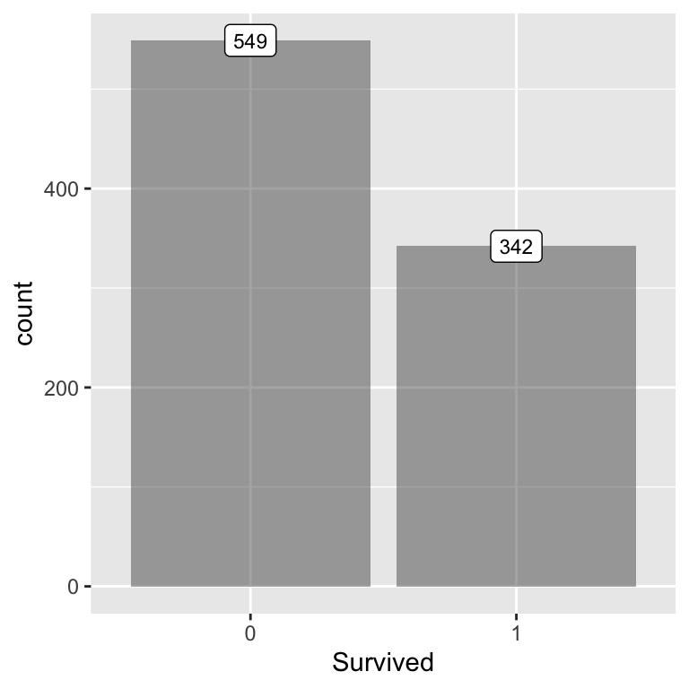

```r
ggplot(train, aes(Survived)) + geom_bar(alpha=0.5) + geom_label(stat = "count", aes(label = ..count.., y = ..count..), size=3)
```

Out of 891 passengers, 549 (62%) died and 342 (38%) survived.

**Duplicates**

There are no duplicates

```r
sum(duplicated(all))
```

```
## [1] 0
```

**Completeness**

We evaluate the **completeness** of the data set.

```r
# Show all columns with NA values in train data set
nacolumn <- which(colSums(is.na(train)) > 0)
sort(colSums(sapply(train[nacolumn], is.na)), decreasing=TRUE)
```

```
## Age
## 177
```

There are 177 entries in `train` which are missing `Age`.

```r
# Show all columns with NA values in test data set
nacolumn <- which(colSums(is.na(test)) > 0)
sort(colSums(sapply(test[nacolumn], is.na)), decreasing=TRUE)
```

```
##  Age Fare
##   86    1
```

86 entries in `test` are missing `Age` and 1 entry is missing `Fare`.

**Missing Values**

**`Age`**

```r
library(mice)
```

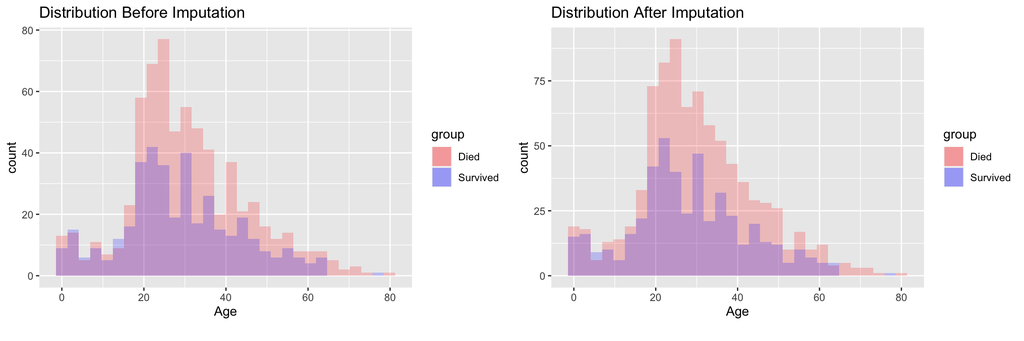

```r
h1 <- ggplot(na.omit(all), aes(Age)) + geom_histogram(data=subset(na.omit(all), Sex=='male'), bins=30, aes(fill="blue"), alpha=0.2) + geom_histogram(data=subset(na.omit(all), Sex=='female'), bins=30, aes(fill="red"), alpha=0.2) + ggtitle('Distribution Before Imputation') + scale_fill_manual(name="group", values=c("red","blue"),labels=c("Died", "Survived"))

# Stochastic regression imputation on column Age
set.seed(1)
imp_df <- data.frame(is.na(all))
imp_df$Fare <- FALSE
imp <- mice(all, method="norm.nob", m=1, where=imp_df)
all <- complete(imp)

# Setting the minimum boundary for Age at 0
all$Age[all$Age < 0] <- 0

h2 <- ggplot(na.omit(all), aes(Age)) + geom_histogram(data=subset(na.omit(all), Sex=='male'), bins=30, aes(fill="blue"), alpha=0.2) + geom_histogram(data=subset(na.omit(all), Sex=='female'), bins=30, aes(fill="red"), alpha=0.2) + ggtitle('Distribution After Imputation') + scale_fill_manual(name="group", values=c("red","blue"),labels=c("Died", "Survived"))

grid.arrange(
  h1, h2,
  nrow=1,
  bottom = textGrob(
    "",
    gp=gpar(fontface=3, fontsize=9),
    hjust=1,
    x=1
  )
)
```

**`Fare`**

We impute the missing `Fare` value in `test`.

```r
all %>% filter(PassengerId==1044)
```

```
##   PassengerId Pclass               Name  Sex  Age SibSp Parch Ticket Fare Cabin
## 1        1044      3 Storey, Mr. Thomas male 60.5     0     0   3701   NA
##   Embarked
## 1        S
```

```r
# Stochastic regression imputation on column Age
set.seed(1)
imp_df <- data.frame(is.na(all))
imp <- mice(all, method="norm.nob", m=1, where=imp_df)
all <- complete(imp)

# Setting the minimum boundary for Fare at 0
all$Fare[all$Fare < 0] <- 0
all %>% filter(PassengerId==1044)
```

```
##   PassengerId Pclass               Name  Sex  Age SibSp Parch Ticket Fare Cabin
## 1        1044      3 Storey, Mr. Thomas male 60.5     0     0   3701    0
##   Embarked
## 1        S
```

There are 15 entries in `train` (18 in `all`) with `Fair` 0. This seems unrealistic but we keep them as they are for now.

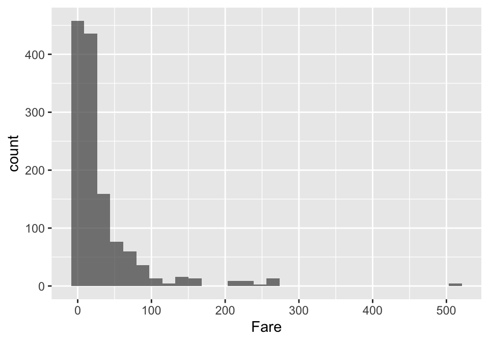

```r
ggplot(na.omit(all), aes(Fare)) + geom_histogram(bins=30, alpha=0.75)
```

```r
all %>% filter(Fare==0)
```

```
##    PassengerId Pclass                                  Name  Sex      Age SibSp
## 1          180      3                   Leonard, Mr. Lionel male 36.00000     0
## 2          264      1                 Harrison, Mr. William male 40.00000     0
## 3          272      3          Tornquist, Mr. William Henry male 25.00000     0
## 4          278      2           Parkes, Mr. Francis "Frank" male 23.19795     0
## 5          303      3       Johnson, Mr. William Cahoone Jr male 19.00000     0
## 6          414      2        Cunningham, Mr. Alfred Fleming male 25.49162     0
## 7          467      2                 Campbell, Mr. William male 34.75740     0
## 8          482      2      Frost, Mr. Anthony Wood "Archie" male 29.88740     0
## 9          598      3                   Johnson, Mr. Alfred male 49.00000     0
## 10         634      1         Parr, Mr. William Henry Marsh male 39.33543     0
## 11         675      2            Watson, Mr. Ennis Hastings male 44.93032     0
## 12         733      2                  Knight, Mr. Robert J male 34.95721     0
## 13         807      1                Andrews, Mr. Thomas Jr male 39.00000     0
## 14         816      1                      Fry, Mr. Richard male 36.88916     0
```

[output cut: 23 more lines]

**`Pclass`, `SibSp`, `Parch`, `Sex` and `Embarked`**

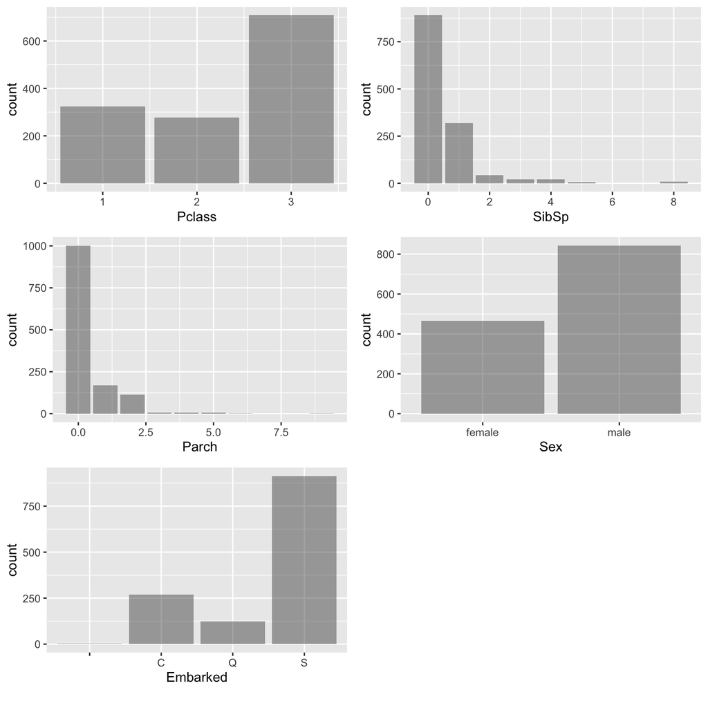

```r
b1 <- ggplot(all, aes(Pclass)) + geom_bar(alpha=0.5)
b2 <- ggplot(all, aes(SibSp)) + geom_bar(alpha=0.5)
b3 <- ggplot(all, aes(Parch)) + geom_bar(alpha=0.5)
b4 <- ggplot(all, aes(Sex)) + geom_bar(alpha=0.5)
b5 <- ggplot(all, aes(Embarked)) + geom_bar(alpha=0.5)
grid.arrange(
  b1, b2, b3, b4, b5,
  nrow=3,
  bottom = textGrob(
    "",
    gp = gpar(fontface=3, fontsize=9),
    hjust=1,
    x=1
  )
)
```

There are 2 entries (`PassengerId` = 62 and 830) in `train` missing `Embarked`. We drop these entries.

```r
all %>% dplyr::group_by(Embarked) %>% dplyr::summarise(n=n())
```

```
## # A tibble: 4 x 2
##   Embarked     n
##   <chr>    <int>
## 1 ""           2
## 2 "C"        270
## 3 "Q"        123
## 4 "S"        914
```

```r
all %>% dplyr::filter(Embarked == '')
```

```
##   PassengerId Pclass                                      Name    Sex Age SibSp
## 1          62      1                       Icard, Miss. Amelie female  38     0
## 2         830      1 Stone, Mrs. George Nelson (Martha Evelyn) female  62     0
##   Parch Ticket Fare Cabin Embarked
## 1     0 113572   80   B28
## 2     0 113572   80   B28
```

```r
# Remove two rows from all
all <- all %>% filter(Embarked != '')
y_train <- y_train %>% filter(PassengerId != 62 & PassengerId != 830)
```

**`Name`**

`Name` is unique except for `Connolly, Miss. Kate` and `Kelly, Mr. James`. Each of these names has 2 entries in the data set. Since they are relatively common names and other column values look different enough, we consider them as different passengers.

```r
length(all$Name)
```

```
## [1] 1307
```

```r
length(unique(all$Name))
```

```
## [1] 1305
```

```r
all %>% group_by(Name) %>% dplyr::summarise(n=n()) %>% filter(n>1)
```

```
## # A tibble: 2 x 2
##   Name                     n
##   <chr>                <int>
## 1 Connolly, Miss. Kate     2
## 2 Kelly, Mr. James         2
```

```r
all %>% filter(Name=='Connolly, Miss. Kate' | Name=='Kelly, Mr. James') %>% arrange(Name)
```

```
##   PassengerId Pclass                 Name    Sex  Age SibSp Parch Ticket   Fare
## 1         290      3 Connolly, Miss. Kate female 22.0     0     0 370373 7.7500
## 2         898      3 Connolly, Miss. Kate female 30.0     0     0 330972 7.6292
## 3         697      3     Kelly, Mr. James   male 44.0     0     0 363592 8.0500
## 4         892      3     Kelly, Mr. James   male 34.5     0     0 330911 7.8292
##   Cabin Embarked
## 1              Q
## 2              Q
## 3              S
## 4              Q
```

**`Ticket`**

`Ticket` values are not unique. Some families/passengers shared the same ticket.

```r
length(unique(all$Ticket))
```

```
## [1] 928
```

```r
all %>% group_by(Ticket) %>% dplyr::summarise(n=n()) %>% filter(n>1) %>% arrange(desc(n)) %>% head()
```

```
## # A tibble: 6 x 2
##   Ticket       n
##   <chr>    <int>
## 1 CA. 2343    11
## 2 1601         8
## 3 CA 2144      8
## 4 3101295      7
## 5 347077       7
## 6 347082       7
```

```r
#train %>% filter(Ticket=='CA. 2343')
#train %>% filter(Ticket=='1601')
#train %>% filter(Ticket=='CA 2144')
#train %>% filter(Ticket=='3101295')
#train %>% filter(Ticket=='347077')
#train %>% filter(Ticket=='347082')
```

**`Cabin`**

```r
all %>% group_by(Cabin) %>% dplyr::summarise(n=n()) %>% arrange(desc(n)) %>% head()
```

```
## # A tibble: 6 x 2
##   Cabin                 n
##   <chr>             <int>
## 1 ""                 1014
## 2 "C23 C25 C27"         6
## 3 "B57 B59 B63 B66"     5
## 4 "G6"                  5
## 5 "B96 B98"             4
## 6 "C22 C26"             4
```

```r
all %>% filter(Cabin != '') %>% head()
```

```
##   PassengerId Pclass                                                Name    Sex
## 1           2      1 Cumings, Mrs. John Bradley (Florence Briggs Thayer) female
## 2           4      1        Futrelle, Mrs. Jacques Heath (Lily May Peel) female
## 3           7      1                             McCarthy, Mr. Timothy J   male
## 4          11      3                     Sandstrom, Miss. Marguerite Rut female
## 5          12      1                            Bonnell, Miss. Elizabeth female
## 6          22      2                               Beesley, Mr. Lawrence   male
##   Age SibSp Parch   Ticket    Fare Cabin Embarked
## 1  38     1     0 PC 17599 71.2833   C85        C
## 2  35     1     0   113803 53.1000  C123        S
## 3  54     0     0    17463 51.8625   E46        S
## 4   4     1     1  PP 9549 16.7000    G6        S
## 5  58     0     0   113783 26.5500  C103        S
## 6  34     0     0   248698 13.0000   D56        S
```

There are 1014 entries with missing `Cabin`.

# 3 Exploratory Data Analysis

**Correlations**

**`Survived` vs `PassengerId`**

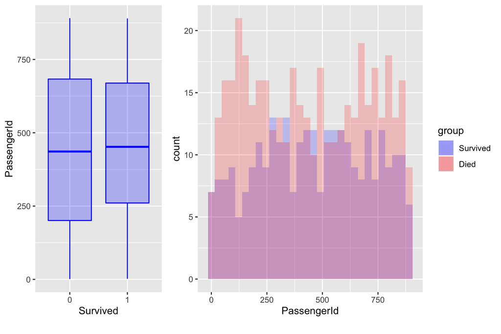

```r
b1 <- ggplot(aes(x=Survived, y=PassengerId), data=na.omit(train)) + geom_boxplot(alpha=0.25, fill='blue', color='blue') +  xlab("Survived")
h1 <- ggplot(na.omit(train), aes(PassengerId)) + geom_histogram(data=subset(na.omit(train), Survived==1), bins=30, aes(fill="blue"), alpha=0.2) + geom_histogram(data=subset(na.omit(train), Survived==0), bins=30, aes(fill="red"), alpha=0.2) + scale_fill_manual(name="group", values=c("blue", "red"), labels=c("Survived", "Died"))
grid.arrange(
  widths = c(0.75, 1.5),
  layout_matrix = rbind(c(1, 2)),
  b1, h1,
  nrow=1,
  bottom=textGrob(
    "",
    gp=gpar(fontface=3, fontsize=9),
    hjust=1,
    x=1
  )
)
```

```r
lm_passengerid_survived = lm(PassengerId ~ Survived, data=na.omit(train))
anova(lm_passengerid_survived)
```

```
## Analysis of Variance Table
##
## Response: PassengerId
##            Df   Sum Sq Mean Sq F value Pr(>F)
## Survived    1    41211   41211  0.6134 0.4338
## Residuals 712 47831696   67179
```

The box plot and the ANOVA output indicates that `PassengerId` has no strong correlation with `Survived`.

**`Survived` vs. Numerical Variables (`Age`, `Fare`)**

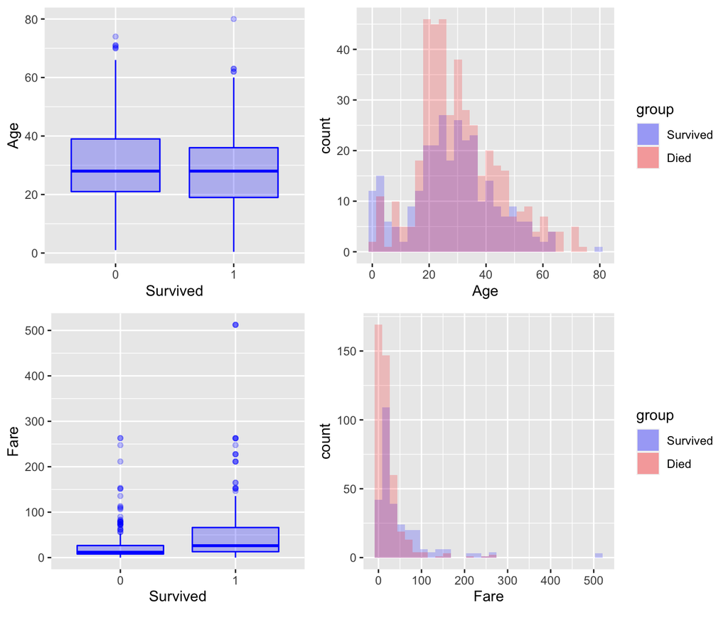

```r
b1 <- ggplot(aes(x=Survived, y=Age), data=na.omit(train)) + geom_boxplot(alpha=0.25, fill='blue', color='blue') +  xlab("Survived")
b2 <- ggplot(aes(x=Survived, y=Fare), data=na.omit(train)) + geom_boxplot(alpha=0.25, fill='blue', color='blue') +  xlab("Survived")
h1 <- ggplot(na.omit(train), aes(Age)) + geom_histogram(data=subset(na.omit(train), Survived==1), bins=30, aes(fill="blue"), alpha=0.2) + geom_histogram(data=subset(na.omit(train), Survived==0), bins=30, aes(fill="red"), alpha=0.2) + scale_fill_manual(name="group", values=c("blue", "red"), labels=c("Survived", "Died"))
h2 <- ggplot(na.omit(train), aes(Fare)) + geom_histogram(data=subset(na.omit(train), Survived==1), bins=30, aes(fill="blue"), alpha=0.2) + geom_histogram(data=subset(na.omit(train), Survived==0), bins=30, aes(fill="red"), alpha=0.2) + scale_fill_manual(name="group", values=c("blue", "red"), labels=c("Survived", "Died"))

grid.arrange(
  widths = c(0.75, 1),
  layout_matrix = rbind(c(1, 2), c(3, 4)),
  b1, h1, b2, h2,
  nrow = 2,
  bottom = textGrob(
    "",
    gp = gpar(fontface = 3, fontsize = 9),
    hjust = 1,
    x = 1
  )
)
```

```r
lm_age_survived = lm(Age ~ Survived, data=na.omit(train))
anova(lm_age_survived)
```

```
## Analysis of Variance Table
##
## Response: Age
##            Df Sum Sq Mean Sq F value  Pr(>F)
## Survived    1    897  897.19  4.2712 0.03912 *
## Residuals 712 149559  210.06
## ---
## Signif. codes:  0 '***' 0.001 '**' 0.01 '*' 0.05 '.' 0.1 ' ' 1
```

```r
lm_fare_survived = lm(Fare ~ Survived, data=na.omit(train))
anova(lm_fare_survived)
```

```
## Analysis of Variance Table
##
## Response: Fare
##            Df  Sum Sq Mean Sq F value    Pr(>F)
## Survived    1  143613  143613  55.179 3.156e-13 ***
## Residuals 712 1853082    2603
## ---
## Signif. codes:  0 '***' 0.001 '**' 0.01 '*' 0.05 '.' 0.1 ' ' 1
```

The outputs of the ANOVA analysis suggest that there are statistically significant differences in the means of `age` and `fare` of those who survived and did not (especially `Fare`). Next, we look into the correlations between the two continuous variables `Fare` and `Age` to evalutate their multicollinearity.

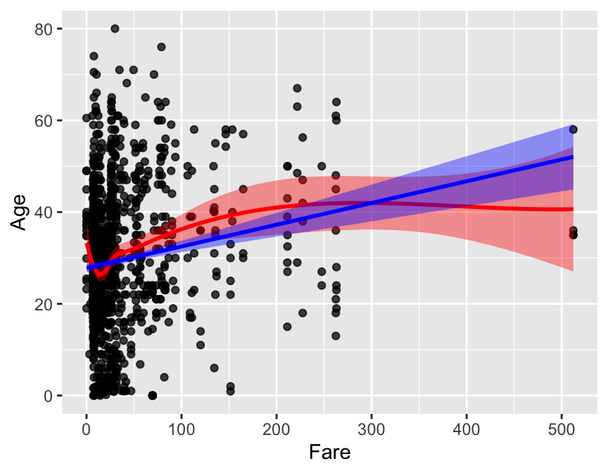

```r
ggplot(na.omit(all), aes(x=Fare, y=Age)) + geom_point(alpha=0.75)+ geom_smooth(method=loess, fill="red", color="red") + geom_smooth(method=lm, fill="blue", color="blue")
```

```r
lm_age_fare = lm(Age ~ Fare, data=na.omit(train))
summary(lm_age_fare)$r.squared
```

```
## [1] 0.009228809
```

The R squared 0.009228809 suggests a weak to non-existing correlation between the two variables.

**`Survived` vs. Categorical Variables `Pclass`, `Sex`, `SibSp`, `Parch`, `Embarked`**

We first convert the following three variables into factor columns: `Pclass`, `SibSp` and `Parch`.

```r
all$Pclass <- as.factor(all$Pclass)
all$Sex <- as.factor(all$Sex)
all$SibSp <- as.factor(all$SibSp)
all$Parch <- as.factor(all$Parch)
all$Embarked <- as.factor(all$Embarked)

train$Pclass <- as.factor(train$Pclass)
train$Sex <- as.factor(train$Sex)
train$SibSp <- as.factor(train$SibSp)
train$Parch <- as.factor(train$Parch)
train$Embarked <- as.factor(train$Embarked)
```

We run pairwise **chi-square tests** for all combinations of the variables (`Survived`, `Pclass`, `Sex`, `SibSp`, `Parch`, `Embarked`) to evaluate the strength of correlation.

```r
# Run chi-square test for all  of categorical variables
library(plyr)
chi_df <- train %>% dplyr::select(Survived, Pclass, Sex, SibSp, Parch, Embarked)
chi_df <- droplevels(chi_df)
combos <- combn(ncol(chi_df), 2)
corelations <- adply(combos, 2, function(x) {
  column_one <- names(chi_df)[x[1]]
  column_two <- names(chi_df)[x[2]]
  mydata <- data.frame(chi_df[, x[1]], chi_df[, x[2]])
  mytab <- table(mydata)
  test <- chisq.test(mytab)
  out <- data.frame('Column.A' = column_one,
                    'Column.B' = column_two,
                    'p.value' = test$p.value)
  return(out)
})

# Correlation between `Survived` and `Pclass`, `Sex`, `SibSp`, `Parch`, `Embarked`
corelations %>% filter(Column.A == 'Survived') %>% arrange(p.value)
```

```
##   X1 Column.A Column.B      p.value
## 1  2 Survived      Sex 1.197357e-58
## 2  1 Survived   Pclass 4.549252e-23
## 3  3 Survived    SibSp 1.558581e-06
## 4  5 Survived Embarked 1.618719e-06
## 5  4 Survived    Parch 9.703526e-05
```

```r
# Correlation between `Pclass`, `Sex`, `SibSp`, `Parch`, `Embarked`
corelations %>% filter(Column.A != 'Survived') %>% arrange(p.value)
```

```
##    X1 Column.A Column.B      p.value
## 1  13    SibSp    Parch 1.790230e-51
## 2   9   Pclass Embarked 1.519464e-25
## 3  11      Sex    Parch 3.816058e-11
## 4  10      Sex    SibSp 8.310305e-08
## 5   7   Pclass    SibSp 9.852350e-07
## 6   6   Pclass      Sex 2.063886e-04
## 7  12      Sex Embarked 7.021496e-04
## 8  14    SibSp Embarked 6.206639e-02
## 9   8   Pclass    Parch 3.785386e-01
## 10 15    Parch Embarked 4.937442e-01
```

**Chi-square tests** of independence show strong dependencies between `Survived` and variables (`Sex`, `Pclass`, `SibSp`, `Embarked`, `Parch`) and between (`Sex`,`Parch`), (`Sex`,`SibSp`), (`Sex`,`Embarked`), (`Sex`, `Pclass`), (`Pclass`,`Embarked`), (`Pclass`,`SibSp`) and (`SibSp`,`Parch`).

**Contingency Tables**

```r
# (Survived, Sex)
table(train$Survived,train$Sex)
```

```
##
##     female male
##   0     81  468
##   1    233  109
```

```r
# (Survived, Pclass)
table(train$Survived,train$Pclass)
```

```
##
##       1   2   3
##   0  80  97 372
##   1 136  87 119
```

```r
# (Survived, SibSp)
table(train$Survived,train$SibSp)
```

```
##
##       0   1   2   3   4   5   8
##   0 398  97  15  12  15   5   7
##   1 210 112  13   4   3   0   0
```

```r
# (Survived, Embarked)
table(train$Survived,train$Embarked)
```

```
##
##           C   Q   S
##   0   0  75  47 427
##   1   2  93  30 217
```

```r
# (Survived, Parch)
table(train$Survived,train$Parch)
```

```
##
##       0   1   2   3   4   5   6
##   0 445  53  40   2   4   4   1
##   1 233  65  40   3   0   1   0
```

Female passenger survival rate is a lot higher than the null hypothesis, where we assume there is difference in the survival rates between female and male passengers. 1st class passengers’ survival rate is significantly higher than that of the 3rd class passengers. Passengers having only one sibling, one spouse, one child or one parent had a higher survival rate than passengers having multiple family members. Passengers who embarked from Cherbourg have a higher survival rate than those from Southampton.

```r
# (Sex, Parch)
table(train$Sex,train$Parch)
```

```
##
##            0   1   2   3   4   5   6
##   female 194  60  49   4   2   4   1
##   male   484  58  31   1   2   1   0
```

```r
# (Sex, SibSp)
table(train$Sex,train$SibSp)
```

```
##
##            0   1   2   3   4   5   8
##   female 174 106  13  11   6   1   3
##   male   434 103  15   5  12   4   4
```

```r
# (Sex, Embarked)
table(train$Sex,train$Embarked)
```

```
##
##                C   Q   S
##   female   2  73  36 203
##   male     0  95  41 441
```

```r
# (Sex, Pclass)
table(train$Sex,train$Pclass)
```

```
##
##            1   2   3
##   female  94  76 144
##   male   122 108 347
```

There are 577 male passengers (0.65) and 314 female passengers (0.35) in `train`. More male passengers traveled independently than female passengers. More male passengers (0.76) embarked from Southampton than female passengers (0.64). There were more female passengers in the first class (0.30) than male passengers (0.21) and more male passengers (0.60) in the third class than the female passengers (0.45).

```r
# (Pclass, Embarked)
table(train$Pclass,train$Embarked)
```

```
##
##           C   Q   S
##   1   2  85   2 127
##   2   0  17   3 164
##   3   0  66  72 353
```

```r
# (Pclass, SibSp)
table(train$Pclass,train$SibSp)
```

```
##
##       0   1   2   3   4   5   8
##   1 137  71   5   3   0   0   0
##   2 120  55   8   1   0   0   0
##   3 351  83  15  12  18   5   7
```

```r
# (SibSp, Parch)
table(train$SibSp,train$Parch)
```

```
##
##       0   1   2   3   4   5   6
##   0 537  38  29   1   1   2   0
##   1 123  57  19   3   3   3   1
##   2  16   7   4   1   0   0   0
##   3   2   7   7   0   0   0   0
##   4   0   9   9   0   0   0   0
##   5   0   0   5   0   0   0   0
##   8   0   0   7   0   0   0   0
```

Majority of the people embarked from Southampton. Half of the passengers who embarked from Cherbourg were in the first class. Over 90% of the passengers from Queenstown were in the third class.

**Numerical (`Age`, `Fare`) vs Categorical (`Pclass`, `Sex`, `SibSp`, `Parch`, `Embarked`)**

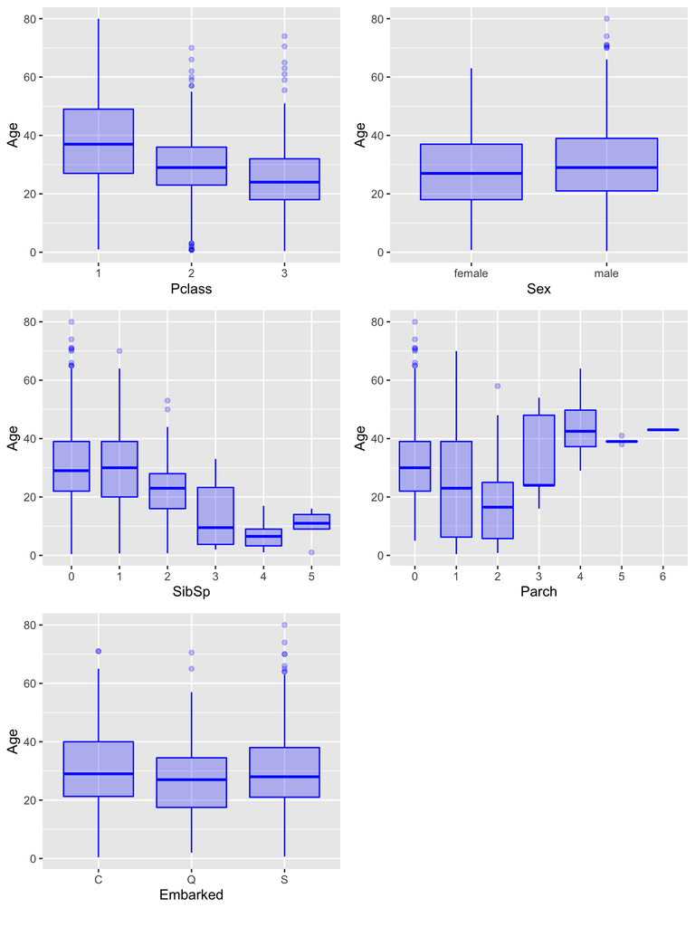

```r
b1 <- ggplot(aes(x=as.factor(Pclass), y=Age), data=na.omit(train)) + geom_boxplot(alpha=0.25, fill='blue', color='blue') +  xlab("Pclass")
b2 <- ggplot(aes(x=Sex, y=Age), data=na.omit(train)) + geom_boxplot(alpha=0.25, fill='blue', color='blue') +  xlab("Sex")
b3 <- ggplot(aes(x=as.factor(SibSp), y=Age), data=na.omit(train)) + geom_boxplot(alpha=0.25, fill='blue', color='blue') +  xlab("SibSp")
b4 <- ggplot(aes(x=as.factor(Parch), y=Age), data=na.omit(train)) + geom_boxplot(alpha=0.25, fill='blue', color='blue') +  xlab("Parch")
b5 <- ggplot(aes(x=as.factor(Embarked), y=Age), data=na.omit(train)) + geom_boxplot(data=subset(na.omit(train), Embarked!=''), alpha=0.25, fill='blue', color='blue') +  xlab("Embarked")
grid.arrange(
  b1, b2, b3, b4, b5,
  nrow = 3,
  bottom = textGrob(
    "",
    gp = gpar(fontface = 3, fontsize = 9),
    hjust = 1,
    x = 1
  )
)
```

The median `Age` of the passengers increases as the level of class increases.

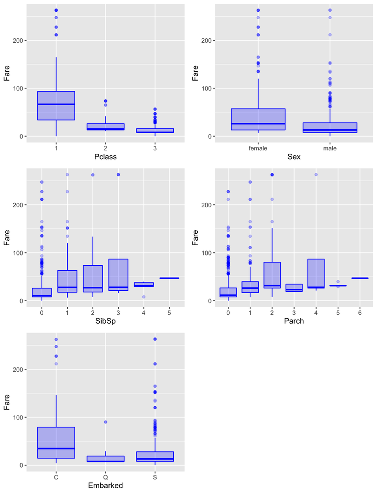

```r
# Exclude Fare > 500
b1 <- ggplot(aes(x=as.factor(Pclass), y=Fare), data=na.omit(train)) + geom_boxplot(data=subset(na.omit(train), Fare<500), alpha=0.25, fill='blue', color='blue') +  xlab("Pclass")
b2 <- ggplot(aes(x=Sex, y=Fare), data=na.omit(train)) + geom_boxplot(data=subset(na.omit(train), Fare<500), alpha=0.25, fill='blue', color='blue') +  xlab("Sex")
b3 <- ggplot(aes(x=as.factor(SibSp), y=Fare), data=na.omit(train)) + geom_boxplot(data=subset(na.omit(train), Fare<500), alpha=0.25, fill='blue', color='blue') +  xlab("SibSp")
b4 <- ggplot(aes(x=as.factor(Parch), y=Fare), data=na.omit(train)) + geom_boxplot(data=subset(na.omit(train), Fare<500), alpha=0.25, fill='blue', color='blue') +  xlab("Parch")
b5 <- ggplot(aes(x=as.factor(Embarked), y=Fare), data=na.omit(train)) + geom_boxplot(data=subset(na.omit(train), Embarked!='' & Fare<500), alpha=0.25, fill='blue', color='blue') +  xlab("Embarked")
grid.arrange(
  b1, b2, b3, b4, b5,
  nrow = 3,
  bottom = textGrob(
    "",
    gp = gpar(fontface = 3, fontsize = 9),
    hjust = 1,
    x = 1
  )
)
```

# 4 Feature Engineering

## 4.1 Transformation

```r
str(all)
```

```
## 'data.frame':    1307 obs. of  11 variables:
##  $ PassengerId: int  1 2 3 4 5 6 7 8 9 10 ...
##  $ Pclass     : Factor w/ 3 levels "1","2","3": 3 1 3 1 3 3 1 3 3 2 ...
##  $ Name       : chr  "Braund, Mr. Owen Harris" "Cumings, Mrs. John Bradley (Florence Briggs Thayer)" "Heikkinen, Miss. Laina" "Futrelle, Mrs. Jacques Heath (Lily May Peel)" ...
##  $ Sex        : Factor w/ 2 levels "female","male": 2 1 1 1 2 2 2 2 1 1 ...
##  $ Age        : num  22 38 26 35 35 ...
##  $ SibSp      : Factor w/ 7 levels "0","1","2","3",..: 2 2 1 2 1 1 1 4 1 2 ...
##  $ Parch      : Factor w/ 8 levels "0","1","2","3",..: 1 1 1 1 1 1 1 2 3 1 ...
##  $ Ticket     : chr  "A/5 21171" "PC 17599" "STON/O2. 3101282" "113803" ...
##  $ Fare       : num  7.25 71.28 7.92 53.1 8.05 ...
##  $ Cabin      : chr  "" "C85" "" "C123" ...
##  $ Embarked   : Factor w/ 3 levels "C","Q","S": 3 1 3 3 3 2 3 3 3 1 ...
```

**`Name`**

We split into `FirstName`, `LastName`, `Title`.

```r
library(stringr)
all$LastName <- str_split_fixed(all$Name, ",", 2)[,1]
tmp <- str_split_fixed(all$Name, ",", 2)[,2]
all$Title <- trimws(str_split_fixed(tmp, "\\.", 2)[,1])
all$FirstName <- str_split_fixed(tmp, "\\.", 2)[,2]
```

We assigned value `Special` to all `Title` values that are not in (Mr, Miss, Mrs). We further drop the columns `Name`, `FirstName` and `LastName`.

```r
all %>% group_by(Title) %>% dplyr::summarise(n=n()) %>% arrange(desc(n))
```

```
## # A tibble: 18 x 2
##    Title            n
##    <chr>        <int>
##  1 Mr             757
##  2 Miss           259
##  3 Mrs            196
##  4 Master          61
##  5 Dr               8
##  6 Rev              8
##  7 Col              4
##  8 Major            2
##  9 Mlle             2
## 10 Ms               2
## 11 Capt             1
## 12 Don              1
## 13 Dona             1
## 14 Jonkheer         1
## 15 Lady             1
## 16 Mme              1
## 17 Sir              1
## 18 the Countess     1
```

```r
all$Title[!(all$Title %in% c('Mr', 'Miss', 'Mrs'))] <- 'Special'
all <- all %>% dplyr::select(-Name, -FirstName, -LastName)
all$Title <- as.factor(all$Title)
```

**`Ticket`**

We extract only alphabet characters from this column.

```r
all$TicketLetters <- sub("^([[:alpha:]]*).*", "\\1", all$Ticket)
all$TicketLetters[all$TicketLetters == ''] <- 'None'
all$TicketLetters[(all$TicketLetters %in% c('LINE', 'PP', 'AQ', 'P', 'WE', 'Fa', 'LP', 'SCO', 'SO', 'SW'))] <- 'Others'
all %>% dplyr::group_by(TicketLetters) %>% dplyr::summarise(n=n()) %>% arrange(desc(n))
```

```
## # A tibble: 12 x 2
##    TicketLetters     n
##    <chr>         <int>
##  1 None            955
##  2 PC               92
##  3 C                55
##  4 A                40
##  5 SOTON            27
##  6 SC               25
##  7 CA               22
##  8 STON             22
##  9 S                21
## 10 Others           19
## 11 W                17
## 12 F                12
```

```r
all$TicketLetters <- as.factor(all$TicketLetters)
all <- all %>% dplyr::select(-Ticket)
```

**`Cabin`**

We create a new attribute `CabinClass` with the first alphabet character stored in this column

```r
all$CabinClass <- sub("^([[:alpha:]]*).*", "\\1", all$Cabin)
all$CabinClass[all$CabinClass == ''] <- 'None'
all$CabinClass[(all$CabinClass %in% c('T','G'))] <- 'None'
all %>% dplyr::group_by(CabinClass) %>% dplyr::summarise(n=n()) %>% arrange(desc(n))
```

```
## # A tibble: 7 x 2
##   CabinClass     n
##   <chr>      <int>
## 1 None        1020
## 2 C             94
## 3 B             63
## 4 D             46
## 5 E             41
## 6 A             22
## 7 F             21
```

```r
all$CabinClass <- as.factor(all$CabinClass)
all <- all %>% dplyr::select(-Cabin)
```

**`FamSizeBinned`**

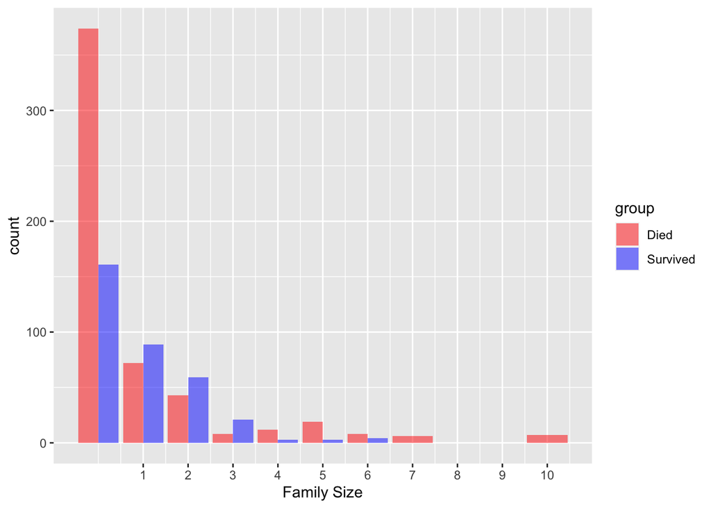

```r
all <- all %>% mutate(FamSize = as.numeric(as.character(SibSp)) + as.numeric(as.character(Parch)))
famsize_df <- merge(y_train, all, by="PassengerId")
ggplot(famsize_df, aes(x=FamSize, fill=as.factor(Survived))) + geom_bar(stat='count', position='dodge', alpha=0.5) + scale_x_continuous(breaks=c(1:11)) + labs(x='Family Size') + theme_grey() + scale_fill_manual(name="group", values=c("red", "blue"),labels=c("Died", "Survived"))
```

```r
all$FamSizeBinned[all$FamSize == 0] <- 'Solo'
all$FamSizeBinned[0 < all$FamSize & all$FamSize <= 3] <- 'Small'
all$FamSizeBinned[3 < all$FamSize] <- 'Large'
all <- all %>% dplyr::select(-FamSize)
all$FamSizeBinned <- as.factor(all$FamSizeBinned)
```

## 4.2 Variable Interaction

# 5 Preprocess

```r
str(all)
```

```
## 'data.frame':    1307 obs. of  12 variables:
##  $ PassengerId  : int  1 2 3 4 5 6 7 8 9 10 ...
##  $ Pclass       : Factor w/ 3 levels "1","2","3": 3 1 3 1 3 3 1 3 3 2 ...
##  $ Sex          : Factor w/ 2 levels "female","male": 2 1 1 1 2 2 2 2 1 1 ...
##  $ Age          : num  22 38 26 35 35 ...
##  $ SibSp        : Factor w/ 7 levels "0","1","2","3",..: 2 2 1 2 1 1 1 4 1 2 ...
##  $ Parch        : Factor w/ 8 levels "0","1","2","3",..: 1 1 1 1 1 1 1 2 3 1 ...
##  $ Fare         : num  7.25 71.28 7.92 53.1 8.05 ...
##  $ Embarked     : Factor w/ 3 levels "C","Q","S": 3 1 3 3 3 2 3 3 3 1 ...
##  $ Title        : Factor w/ 4 levels "Miss","Mr","Mrs",..: 2 3 1 3 2 2 2 4 3 3 ...
##  $ TicketLetters: Factor w/ 12 levels "A","C","CA","F",..: 1 7 11 5 5 5 5 5 5 5 ...
##  $ CabinClass   : Factor w/ 7 levels "A","B","C","D",..: 7 3 7 3 7 7 5 7 7 7 ...
##  $ FamSizeBinned: Factor w/ 3 levels "Large","Small",..: 2 2 3 2 3 3 3 1 2 2 ...
```

## 5.1 Outliers

## 5.2 Normalization

We normalize the two continuous variables: `Age` and `Fare`.

```r
library(caret)
preProc <- preProcess(all[,-1], method=c("center", "scale"))
preProc
```

```
## Created from 1307 samples and 11 variables
##
## Pre-processing:
##   - centered (2)
##   - ignored (9)
##   - scaled (2)
```

```r
all <- predict(preProc, all)
```

## 5.3 Encoding

We take one-hot encoding of the factor variables.

```r
str(all)
```

```
## 'data.frame':    1307 obs. of  12 variables:
##  $ PassengerId  : int  1 2 3 4 5 6 7 8 9 10 ...
##  $ Pclass       : Factor w/ 3 levels "1","2","3": 3 1 3 1 3 3 1 3 3 2 ...
##  $ Sex          : Factor w/ 2 levels "female","male": 2 1 1 1 2 2 2 2 1 1 ...
##  $ Age          : num  -0.515 0.607 -0.234 0.396 0.396 ...
##  $ SibSp        : Factor w/ 7 levels "0","1","2","3",..: 2 2 1 2 1 1 1 4 1 2 ...
##  $ Parch        : Factor w/ 8 levels "0","1","2","3",..: 1 1 1 1 1 1 1 2 3 1 ...
##  $ Fare         : num  -0.501 0.736 -0.488 0.385 -0.486 ...
##  $ Embarked     : Factor w/ 3 levels "C","Q","S": 3 1 3 3 3 2 3 3 3 1 ...
##  $ Title        : Factor w/ 4 levels "Miss","Mr","Mrs",..: 2 3 1 3 2 2 2 4 3 3 ...
##  $ TicketLetters: Factor w/ 12 levels "A","C","CA","F",..: 1 7 11 5 5 5 5 5 5 5 ...
##  $ CabinClass   : Factor w/ 7 levels "A","B","C","D",..: 7 3 7 3 7 7 5 7 7 7 ...
##  $ FamSizeBinned: Factor w/ 3 levels "Large","Small",..: 2 2 3 2 3 3 3 1 2 2 ...
```

```r
# Drop levels with no entries
all <- droplevels(all)
# One-hot encoding using model.matrix()
all <- as.data.frame(model.matrix( ~ . -1, all))
# Standarize weird column names
colnames(all) <- make.names(colnames(all))
str(all)
```

```
## 'data.frame':    1307 obs. of  44 variables:
##  $ PassengerId        : num  1 2 3 4 5 6 7 8 9 10 ...
##  $ Pclass1            : num  0 1 0 1 0 0 1 0 0 0 ...
##  $ Pclass2            : num  0 0 0 0 0 0 0 0 0 1 ...
##  $ Pclass3            : num  1 0 1 0 1 1 0 1 1 0 ...
##  $ Sexmale            : num  1 0 0 0 1 1 1 1 0 0 ...
##  $ Age                : num  -0.515 0.607 -0.234 0.396 0.396 ...
##  $ SibSp1             : num  1 1 0 1 0 0 0 0 0 1 ...
##  $ SibSp2             : num  0 0 0 0 0 0 0 0 0 0 ...
##  $ SibSp3             : num  0 0 0 0 0 0 0 1 0 0 ...
##  $ SibSp4             : num  0 0 0 0 0 0 0 0 0 0 ...
##  $ SibSp5             : num  0 0 0 0 0 0 0 0 0 0 ...
##  $ SibSp8             : num  0 0 0 0 0 0 0 0 0 0 ...
##  $ Parch1             : num  0 0 0 0 0 0 0 1 0 0 ...
##  $ Parch2             : num  0 0 0 0 0 0 0 0 1 0 ...
```

[output cut: 30 more lines]

## 5.4 Cleaning

We drop factor levels with no entries, remove near zero variance variables and collinear variables.

```r
# Drop levels with no entries
all <- droplevels(all)

# Remove variables with zero (near zero) variance
drop_zerovar <- nearZeroVar(all)
colnames(all[, c(drop_zerovar)])
```

```
##  [1] "SibSp2"              "SibSp3"              "SibSp4"
##  [4] "SibSp5"              "SibSp8"              "Parch3"
##  [7] "Parch4"              "Parch5"              "Parch6"
## [10] "Parch9"              "TicketLettersC"      "TicketLettersCA"
## [13] "TicketLettersF"      "TicketLettersOthers" "TicketLettersS"
## [16] "TicketLettersSC"     "TicketLettersSOTON"  "TicketLettersSTON"
## [19] "TicketLettersW"      "CabinClassB"         "CabinClassD"
## [22] "CabinClassE"         "CabinClassF"
```

```r
all <- all[, -c(drop_zerovar)]

# Remove perfectly collinear columns
drop_collinear <- c(rownames(alias(lm(PassengerId ~ . , data=all))$Complete))
drop_collinear
```

```
## [1] "Pclass3"
```

```r
all <- all %>% dplyr::select(-all_of(drop_collinear))
```

# 6 Feature Importance

We use random forest with 100 trees to quickly evaluate the important features.

```r
# Run a quick random forest with 100 trees to find important features
library(randomForest)
```

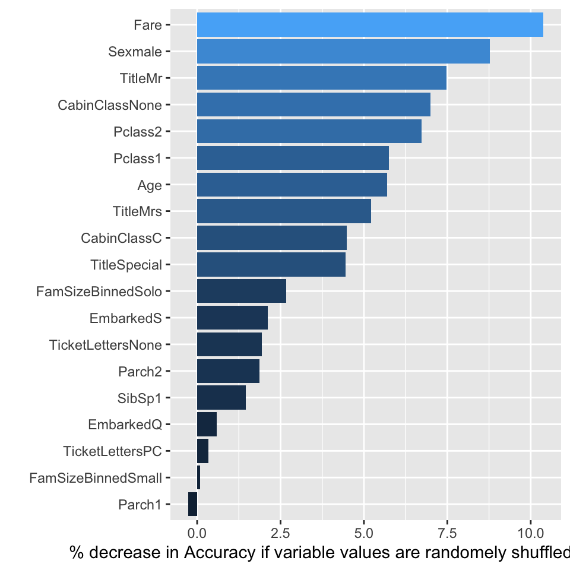

```r
rf_df <- merge(y_train, all, by="PassengerId")
set.seed(1)
model_rf <- randomForest(as.factor(Survived) ~ . -PassengerId, data=rf_df, ntree=100, importance=TRUE)
imp_RF <- importance(model_rf)
imp_DF <- data.frame(Variables=row.names(imp_RF), MDA=imp_RF[,1])
imp_DF <- imp_DF[order(imp_DF$MDA, decreasing=TRUE),]
imp_var <- c(imp_DF[,'Variables'])
ggplot(imp_DF, aes(x=reorder(Variables, MDA), y=MDA, fill=MDA)) + geom_bar(stat='identity') + labs(x='', y='% decrease in Accuracy if variable values are randomely shuffled (permuted)') + coord_flip() + theme(legend.position="none")
```

```r
# We drop features with negative importance
important_features <- imp_DF %>% filter(MDA>0) %>% rownames()
important_features
```

```
##  [1] "Fare"               "Sexmale"            "TitleMr"
##  [4] "CabinClassNone"     "Pclass2"            "Pclass1"
##  [7] "Age"                "TitleMrs"           "CabinClassC"
## [10] "TitleSpecial"       "FamSizeBinnedSolo"  "EmbarkedS"
## [13] "TicketLettersNone"  "Parch2"             "SibSp1"
## [16] "EmbarkedQ"          "TicketLettersPC"    "FamSizeBinnedSmall"
```

```r
all <- all %>% dplyr::select(PassengerId, all_of(important_features))
```

# 7 Modeling

```r
train <- merge(y_train, all, by="PassengerId")
test <- merge(y_train, all, by="PassengerId", all=TRUE) %>% filter(is.na(Survived))
```

## 7.1 Linear / Quadratic Discrimnant Analysis

LDA uses continuous independent variables and a categorical dependent variable. It tries to find a linear hyperplane that maximizes the ratio between the within class variance and the inter class variance. Following are the fundamental assumptions of LDA (from wiki):

1. **multivariate normality**: independent variables are distributed normally for each level of the grouping variable.
2. **homogeneity of variance / covariance (homoscedasticity)**: variances among group variables are the same across levels of predictors. This can be tested with **Box’s M** statistic. **Linear discriminant analysis** are typically used when the covariances are equal and **quadratic discriminant analysis** when covariances are not equal.
3. **multicollinearity**: predictive power can decrease with an increased correlation between predictor variables.
4. **independence**: observations are assumed to be randomly sampled, and a participant’s score on one variable is assumed to be independent of scores on that variable for all other participants.

```r
# Linear Discriminant Analysis
library(pROC)
model.lda <- lda(as.factor(Survived) ~ . -PassengerId, data=train)
pred.lda <- predict(model.lda, train)
confusionMatrix(pred.lda$class, as.factor(train$Survived))
```

```
## Confusion Matrix and Statistics
##
##           Reference
## Prediction   0   1
##          0 481  85
##          1  68 255
##
##                Accuracy : 0.8279
##                  95% CI : (0.8014, 0.8522)
##     No Information Rate : 0.6175
##     P-Value [Acc > NIR] : <2e-16
##
##                   Kappa : 0.6322
##
##  Mcnemar's Test P-Value : 0.1958
##
##             Sensitivity : 0.8761
##             Specificity : 0.7500
##          Pos Pred Value : 0.8498
##          Neg Pred Value : 0.7895
##              Prevalence : 0.6175
##          Detection Rate : 0.5411
##    Detection Prevalence : 0.6367
##       Balanced Accuracy : 0.8131
##
##        'Positive' Class : 0
##
```

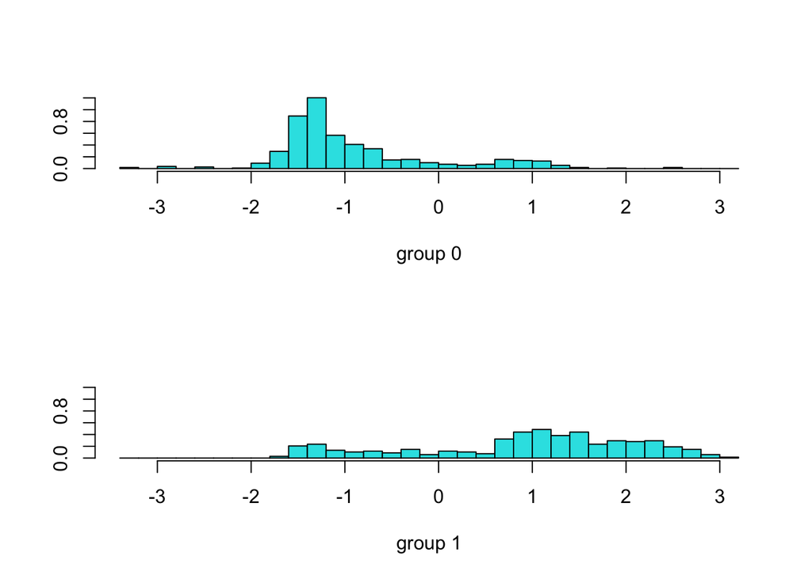

```r
plot(model.lda)
```

```r
roc.lda <- roc(response=train$Survived, predictor=pred.lda$posterior[,1])
```

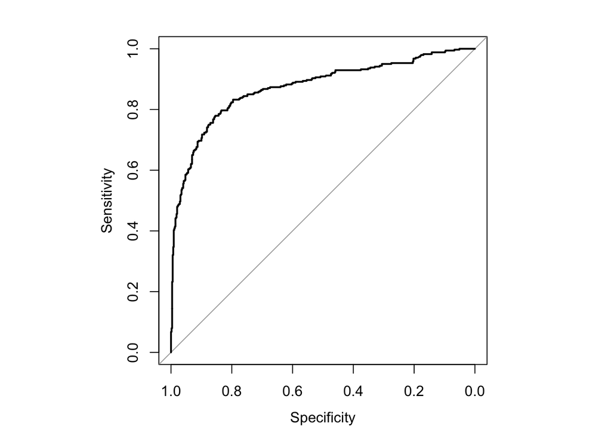

```r
par(pty="s")
plot(roc.lda)
```

```r
auc(roc.lda)
```

```
## Area under the curve: 0.8728
```

We run **Box’s M** test to evaluate if the second assumption above is met.

```r
# Box's M-Test for homogeneity of covariance matrices obtained from multivariate normal data according to one or more classification factors
library(biotools)
as.numeric(ncol(train)-2)
```

```
## [1] 18
```

```r
boxM(train[,3:as.numeric(ncol(train)-2)], train[,2])
```

```
##
##  Box's M-test for Homogeneity of Covariance Matrices
##
## data:  train[, 3:as.numeric(ncol(train) - 2)]
## Chi-Sq (approx.) = 18911, df = 136, p-value < 2.2e-16
```

The null hypothesis for this test is that the observed covariance matrices for the dependent variables are equal across groups. The test result with a small p-value indicates that the covariances are not equal. We run quadratic discriminant analysis.

```r
# Quadratic Discriminant Analysis (removing `TitleSpecial` because it causes a rank deficiency problem...)
model.qda <- qda(as.factor(Survived) ~ . -PassengerId -TitleSpecial, data=train)
pred.qda <- predict(model.qda, train)
confusionMatrix(pred.qda$class, as.factor(train$Survived))
```

```
## Confusion Matrix and Statistics
##
##           Reference
## Prediction   0   1
##          0 449  68
##          1 100 272
##
##                Accuracy : 0.811
##                  95% CI : (0.7837, 0.8363)
##     No Information Rate : 0.6175
##     P-Value [Acc > NIR] : < 2e-16
##
##                   Kappa : 0.607
##
##  Mcnemar's Test P-Value : 0.01677
##
##             Sensitivity : 0.8179
##             Specificity : 0.8000
##          Pos Pred Value : 0.8685
##          Neg Pred Value : 0.7312
##              Prevalence : 0.6175
##          Detection Rate : 0.5051
##    Detection Prevalence : 0.5816
##       Balanced Accuracy : 0.8089
##
##        'Positive' Class : 0
##
```

```r
roc.qda <- roc(response=train$Survived, predictor=pred.qda$posterior[,1])
```

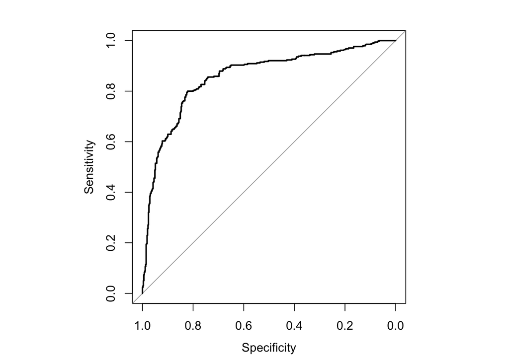

```r
par(pty="s")
plot(roc.qda)
```

```r
auc(roc.qda)
```

```
## Area under the curve: 0.8574
```

```r
test$Survived <- predict(model.lda, test)$class
submission.lda <- test %>% dplyr::select(PassengerId, Survived)
write.csv(submission.lda,"submission_lda.csv", row.names=FALSE) # 0.78947

test$Survived <- predict(model.qda, test)$class
submission.qda <- test %>% dplyr::select(PassengerId, Survived)
write.csv(submission.qda,"submission_qda.csv", row.names=FALSE) # 0.73205
```

## 7.2 Logistic Regressions (Generalized Linear Model)

We try various logistic regression models with `caret` to choose the optimal hyperparameter using cross validation. We start with a **simple logistic regression**.

```r
model.logistic <- glm(as.factor(Survived) ~ . - PassengerId , data=train, family=binomial)
prob.logistic <- predict(model.logistic, train, type="response")

class.logistic <- rep("0", dim(train)[1])
class.logistic[prob.logistic > .5] = "1"
confusionMatrix(as.factor(class.logistic), as.factor(train$Survived))
```

```
## Confusion Matrix and Statistics
##
##           Reference
## Prediction   0   1
##          0 476  81
##          1  73 259
##
##                Accuracy : 0.8268
##                  95% CI : (0.8003, 0.8511)
##     No Information Rate : 0.6175
##     P-Value [Acc > NIR] : <2e-16
##
##                   Kappa : 0.6316
##
##  Mcnemar's Test P-Value : 0.5727
##
##             Sensitivity : 0.8670
##             Specificity : 0.7618
##          Pos Pred Value : 0.8546
##          Neg Pred Value : 0.7801
##              Prevalence : 0.6175
##          Detection Rate : 0.5354
##    Detection Prevalence : 0.6265
##       Balanced Accuracy : 0.8144
##
##        'Positive' Class : 0
##
```

```r
roc.logistic <- roc(response=train$Survived, predictor=prob.logistic)
```

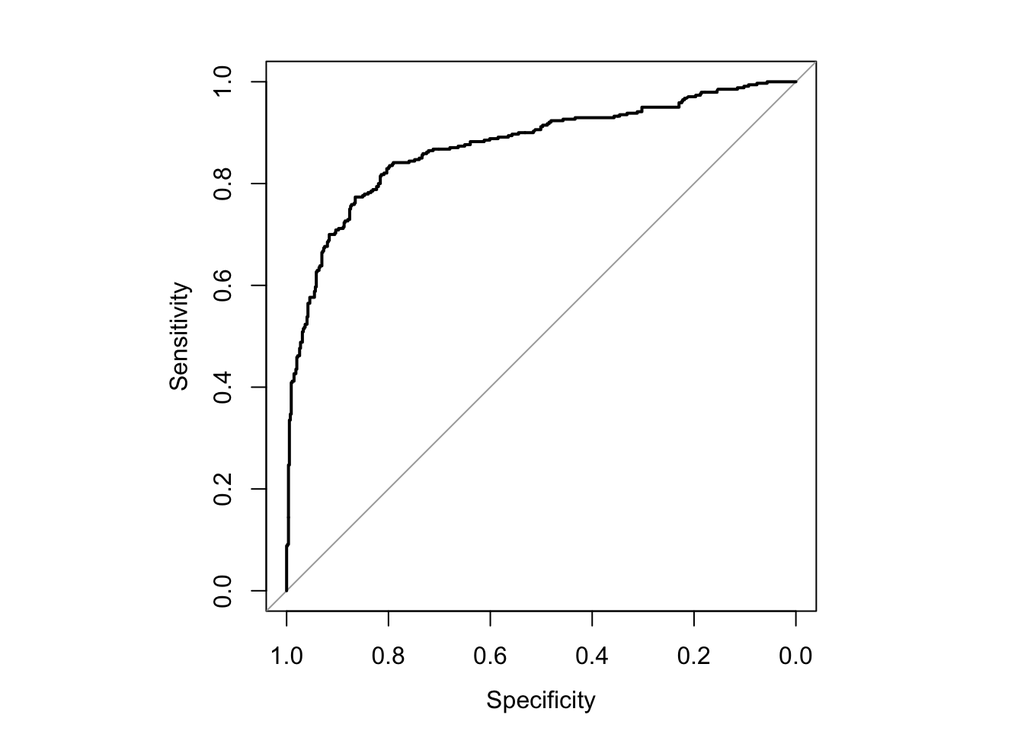

```r
par(pty="s")
plot(roc.logistic)
```

```r
auc(roc.logistic)
```

```
## Area under the curve: 0.8737
```

Next, we use **elastic net** logistic regression with penalty both on L1 and L2 norm.

```r
## Set training control for model building
set.seed(1)
ctrl <- trainControl(method="repeatedcv", number=5, repeats=10, summaryFunction=twoClassSummary, classProbs=TRUE, savePredictions=TRUE, search="random")
model.elastic <- train(make.names(as.factor(Survived)) ~ . - PassengerId, data=train, method="glmnet", family="binomial", metric="ROC", trControl=ctrl, Length=10)
model.elastic$bestTune
```

```
##       alpha    lambda
## 1 0.2016819 0.3764085
```

```r
class.elastic <- predict(model.elastic, train, type='raw')
confusionMatrix(as.factor(class.elastic), as.factor(make.names(train$Survived)))
```

```
## Confusion Matrix and Statistics
##
##           Reference
## Prediction  X0  X1
##         X0 509 159
##         X1  40 181
##
##                Accuracy : 0.7762
##                  95% CI : (0.7473, 0.8032)
##     No Information Rate : 0.6175
##     P-Value [Acc > NIR] : < 2.2e-16
##
##                   Kappa : 0.4923
##
##  Mcnemar's Test P-Value : < 2.2e-16
##
##             Sensitivity : 0.9271
##             Specificity : 0.5324
##          Pos Pred Value : 0.7620
##          Neg Pred Value : 0.8190
##              Prevalence : 0.6175
##          Detection Rate : 0.5726
##    Detection Prevalence : 0.7514
##       Balanced Accuracy : 0.7297
##
##        'Positive' Class : X0
##
```

```r
prob.elastic <- predict(model.elastic, train, type='prob')[,1]
roc.elastic <- roc(response=train$Survived, predictor=prob.elastic)
```

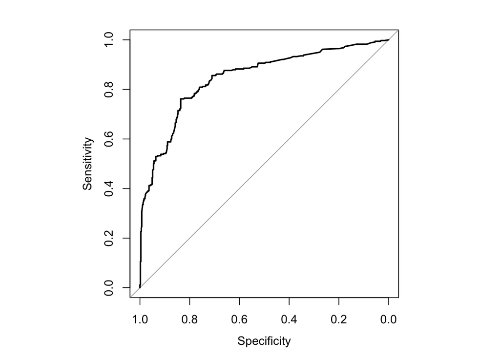

```r
par(pty="s")
plot(roc.elastic)
```

```r
auc(roc.elastic)
```

```
## Area under the curve: 0.8464
```

Lastly, we use **kernel logistic regression** (package dependency problem unresolved).

```r
#library(mixOmics)
#library(mixKernel)
#K <- compute.kernel(train[, 3:19], kernel.func="gaussian.radial.basis")
#gelnet.klr(K, train$Survived, lambda=0.3764085, max.iter=100, eps=1e-05, v.init=rep(0,nrow(K)), b.init=0.5, silent=FALSE)
```

```r
test$Survived <- predict(model.logistic, test)
test$Survived[test$Survived >  0.5] <- 1
test$Survived[test$Survived <= 0.5] <- 0
submission.logistic <- test %>% dplyr::select(PassengerId, Survived)
write.csv(submission.logistic,"submission_logistic.csv", row.names=FALSE) # 0.77511
```

## 7.3 KNN (Nonparametric Model)

```r
library(class)
trControl <- trainControl(method="cv", number=10)
model.knn <- train(as.factor(Survived) ~ . -PassengerId, data=train, method="knn", tuneGrid=expand.grid(k=1:10), trControl=trControl, metric="Accuracy")
model.knn$bestTune
```

```
##   k
## 5 5
```

```r
class.knn <- predict(model.knn, train, type='raw')
confusionMatrix(as.factor(class.knn), as.factor(train$Survived))
```

```
## Confusion Matrix and Statistics
##
##           Reference
## Prediction   0   1
##          0 495  71
##          1  54 269
##
##                Accuracy : 0.8594
##                  95% CI : (0.8348, 0.8816)
##     No Information Rate : 0.6175
##     P-Value [Acc > NIR] : <2e-16
##
##                   Kappa : 0.6995
##
##  Mcnemar's Test P-Value : 0.1524
##
##             Sensitivity : 0.9016
##             Specificity : 0.7912
##          Pos Pred Value : 0.8746
##          Neg Pred Value : 0.8328
##              Prevalence : 0.6175
##          Detection Rate : 0.5568
##    Detection Prevalence : 0.6367
##       Balanced Accuracy : 0.8464
##
##        'Positive' Class : 0
##
```

```r
prob.knn <- predict(model.knn, train, type='prob')[,1]
roc.knn <- roc(response=train$Survived, predictor=prob.knn)
```

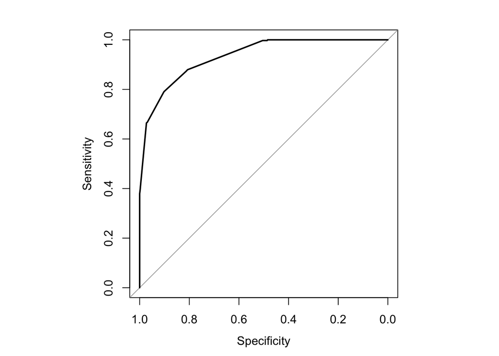

```r
par(pty="s")
plot(roc.knn)
```

```r
auc(roc.knn)
```

```
## Area under the curve: 0.9331
```

```r
test$Survived <- predict(model.knn, test, type='raw')
submission.knn <- test %>% dplyr::select(PassengerId, Survived)
write.csv(submission.knn,"submission_knn.csv", row.names=FALSE) # 0.72727
```

## 7.4 Logistic Generalized Additive Model

GAMs fit multiple basis functions to the observation to capture nonlinear relationships. GAMs require more data than linear models, but could be more powerful because of their flexibility, which in turn could become a risk of over-fitting.

```r
library(mgcv)
# Remove 'TitleSpecial' because it causes a problem...
model.gam <- gam(as.factor(Survived) ~ s(Age) + s(Fare) + Sexmale + Pclass1 + Pclass2 + SibSp1 + Parch2 + EmbarkedQ + EmbarkedS + TitleMr + TitleMrs + TicketLettersNone + TicketLettersPC + CabinClassC + CabinClassNone, data=train, family=binomial, method="REML")
summary(model.gam)
```

```
##
## Family: binomial
## Link function: logit
##
## Formula:
## as.factor(Survived) ~ s(Age) + s(Fare) + Sexmale + Pclass1 +
##     Pclass2 + SibSp1 + Parch2 + EmbarkedQ + EmbarkedS + TitleMr +
##     TitleMrs + TicketLettersNone + TicketLettersPC + CabinClassC +
##     CabinClassNone
##
## Parametric coefficients:
##                   Estimate Std. Error z value Pr(>|z|)
## (Intercept)        1.99571    0.54359   3.671 0.000241 ***
## Sexmale           -1.13075    0.35013  -3.229 0.001240 **
## Pclass1            1.57917    0.45549   3.467 0.000526 ***
## Pclass2            1.10005    0.24674   4.458 8.26e-06 ***
## SibSp1             0.06572    0.23017   0.286 0.775225
## Parch2            -0.56476    0.33557  -1.683 0.092380 .
## EmbarkedQ         -0.18338    0.38986  -0.470 0.638096
## EmbarkedS         -0.65193    0.25128  -2.594 0.009474 **
## TitleMr           -1.60054    0.35304  -4.534 5.80e-06 ***
## TitleMrs           0.42596    0.33458   1.273 0.202976
## TicketLettersNone -0.14279    0.25601  -0.558 0.577008
## TicketLettersPC   -0.50161    0.51818  -0.968 0.333035
## CabinClassC       -0.72997    0.41802  -1.746 0.080769 .
## CabinClassNone    -1.25168    0.37406  -3.346 0.000819 ***
## ---
## Signif. codes:  0 '***' 0.001 '**' 0.01 '*' 0.05 '.' 0.1 ' ' 1
##
## Approximate significance of smooth terms:
##           edf Ref.df Chi.sq p-value
## s(Age)  2.159  2.756  10.17  0.0117 *
## s(Fare) 1.668  2.091   0.90  0.6317
## ---
## Signif. codes:  0 '***' 0.001 '**' 0.01 '*' 0.05 '.' 0.1 ' ' 1
##
## R-sq.(adj) =   0.42   Deviance explained = 35.6%
## -REML = 391.41  Scale est. = 1         n = 889
```

```r
prob.gam <- predict(model.gam, train, type="response")
class.gam <- rep("0", dim(train)[1])
class.gam[prob.gam > .5] = "1"
confusionMatrix(as.factor(class.gam), as.factor(train$Survived))
```

```
## Confusion Matrix and Statistics
##
##           Reference
## Prediction   0   1
##          0 464  87
##          1  85 253
##
##                Accuracy : 0.8065
##                  95% CI : (0.779, 0.832)
##     No Information Rate : 0.6175
##     P-Value [Acc > NIR] : <2e-16
##
##                   Kappa : 0.59
##
##  Mcnemar's Test P-Value : 0.9392
##
##             Sensitivity : 0.8452
##             Specificity : 0.7441
##          Pos Pred Value : 0.8421
##          Neg Pred Value : 0.7485
##              Prevalence : 0.6175
##          Detection Rate : 0.5219
##    Detection Prevalence : 0.6198
##       Balanced Accuracy : 0.7946
##
##        'Positive' Class : 0
##
```

```r
roc.gam <- roc(response=train$Survived, predictor=prob.gam)
```

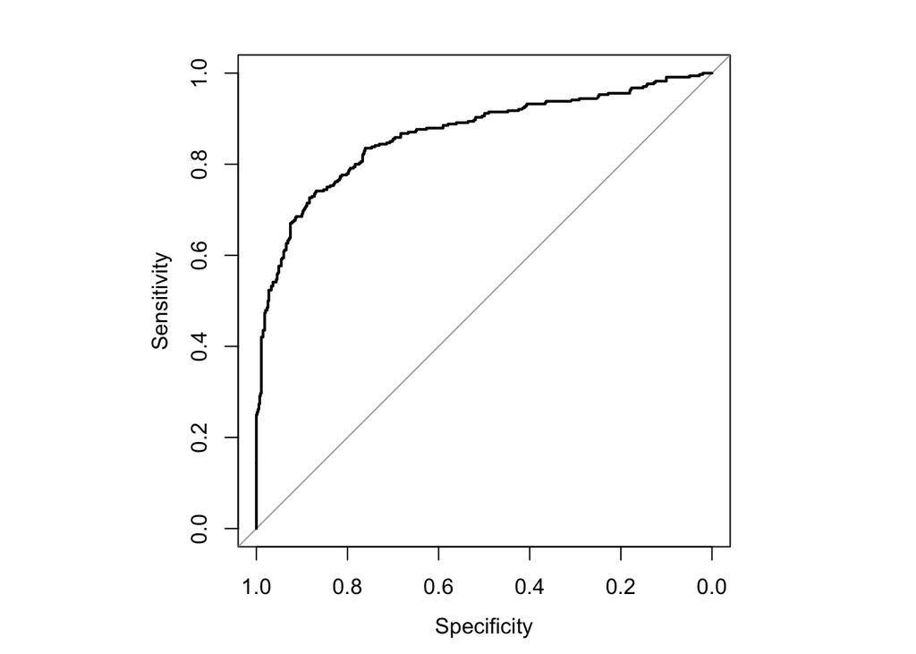

```r
par(pty="s")
plot(roc.gam)
```

```r
auc(roc.gam)
```

```
## Area under the curve: 0.8651
```

```r
test$Survived <- predict(model.gam, test)
test$Survived[test$Survived >  0.5] <- 1
test$Survived[test$Survived <= 0.5] <- 0
submission.gam <- test %>% dplyr::select(PassengerId, Survived)
write.csv(submission.gam,"submission_gam.csv", row.names=FALSE) # 0.77511
```

## 7.5 Support Vector Machine

```r
library(e1071)
set.seed(1)
tuneResult <- tune(svm, as.factor(Survived) ~ . -PassengerId, data=train, ranges=list(gamma=2^(-5:0), cost=seq(0.5,1.5,0.1)), kernel="radial", probability=TRUE)
print(tuneResult)
```

```
##
## Parameter tuning of 'svm':
##
## - sampling method: 10-fold cross validation
##
## - best parameters:
##    gamma cost
##  0.03125  0.8
##
## - best performance: 0.173238
```

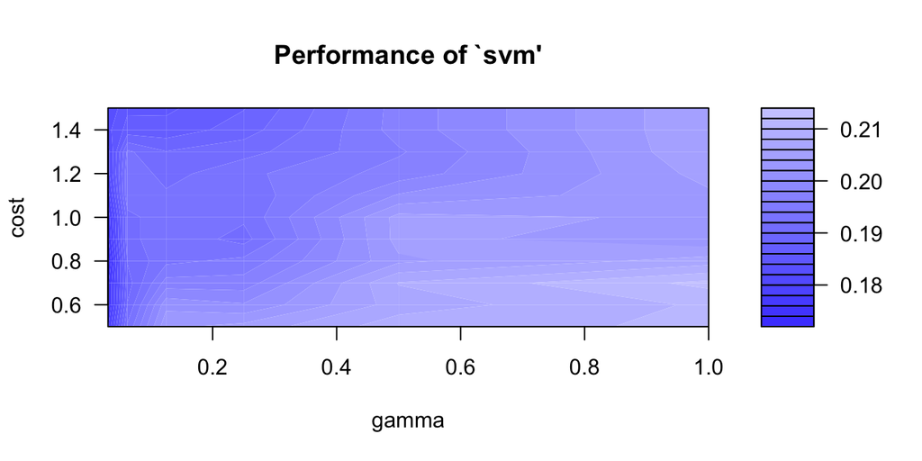

```r
plot(tuneResult)
```

```r
model.svm <- tuneResult$best.model
class.svm <- predict(model.svm, train)
pred.svm <- predict(model.svm, train, probability=TRUE)
prob.svm <- attr(pred.svm, "probabilities")[,1]
confusionMatrix(as.factor(pred.svm), as.factor(train$Survived))
```

```
## Confusion Matrix and Statistics
##
##           Reference
## Prediction   0   1
##          0 490  84
##          1  59 256
##
##                Accuracy : 0.8391
##                  95% CI : (0.8133, 0.8627)
##     No Information Rate : 0.6175
##     P-Value [Acc > NIR] : < 2e-16
##
##                   Kappa : 0.6546
##
##  Mcnemar's Test P-Value : 0.04475
##
##             Sensitivity : 0.8925
##             Specificity : 0.7529
##          Pos Pred Value : 0.8537
##          Neg Pred Value : 0.8127
##              Prevalence : 0.6175
##          Detection Rate : 0.5512
##    Detection Prevalence : 0.6457
##       Balanced Accuracy : 0.8227
##
##        'Positive' Class : 0
##
```

```r
roc.gam <- roc(response=train$Survived, predictor=prob.svm)
```

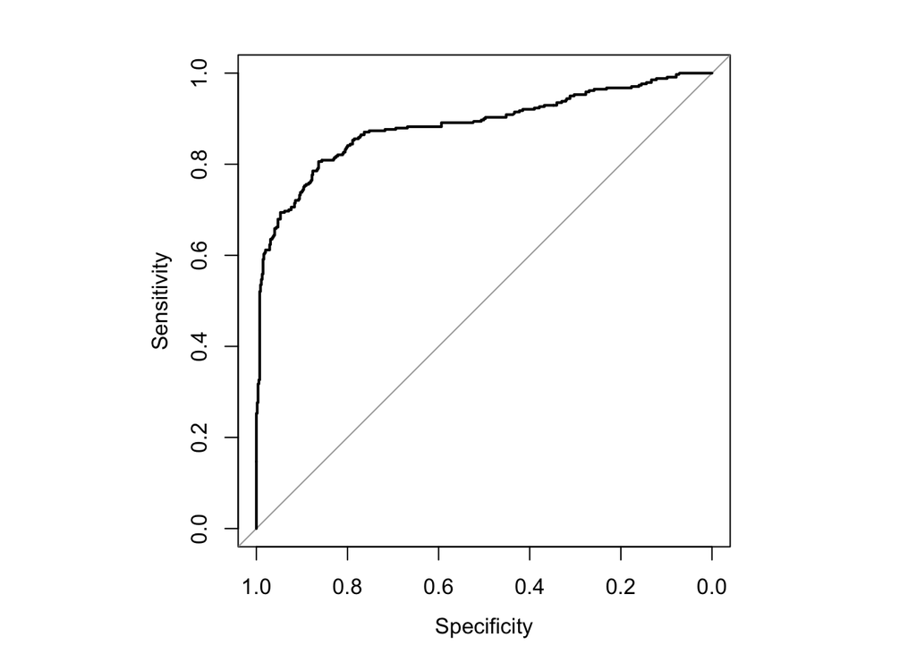

```r
par(pty="s")
plot(roc.gam)
```

```r
auc(roc.gam)
```

```
## Area under the curve: 0.8853
```

```r
test$Survived <- predict(model.svm, test)
submission.svm <- test %>% dplyr::select(PassengerId, Survived)
write.csv(submission.svm,"submission_svm.csv", row.names=FALSE) # 0.75119
```

## 7.6 Naive Bayes Classifier

The fundamental Naive Bayes assumption is that each feature makes an independent and equal contribution to the outcome.

```r
library(klaR)
set.seed(1)
trControl <- trainControl(method="cv", number=5, classProbs=TRUE)
model.nb <- train(make.names(as.factor(Survived)) ~ . -PassengerId, train, method="nb", trControl=trControl)
pred.nb <- predict(model.nb, train)
```

```r
class.nb <- predict(model.nb, train, type='raw')
confusionMatrix(as.factor(class.nb), as.factor(make.names(train$Survived)))
```

```
## Confusion Matrix and Statistics
##
##           Reference
## Prediction  X0  X1
##         X0 441 103
##         X1 108 237
##
##                Accuracy : 0.7627
##                  95% CI : (0.7333, 0.7903)
##     No Information Rate : 0.6175
##     P-Value [Acc > NIR] : <2e-16
##
##                   Kappa : 0.4989
##
##  Mcnemar's Test P-Value : 0.783
##
##             Sensitivity : 0.8033
##             Specificity : 0.6971
##          Pos Pred Value : 0.8107
##          Neg Pred Value : 0.6870
##              Prevalence : 0.6175
##          Detection Rate : 0.4961
##    Detection Prevalence : 0.6119
##       Balanced Accuracy : 0.7502
##
##        'Positive' Class : X0
##
```

```r
prob.nb <- predict(model.nb, train, type='prob')[,1]
roc.nb <- roc(response=train$Survived, predictor=prob.nb)
```

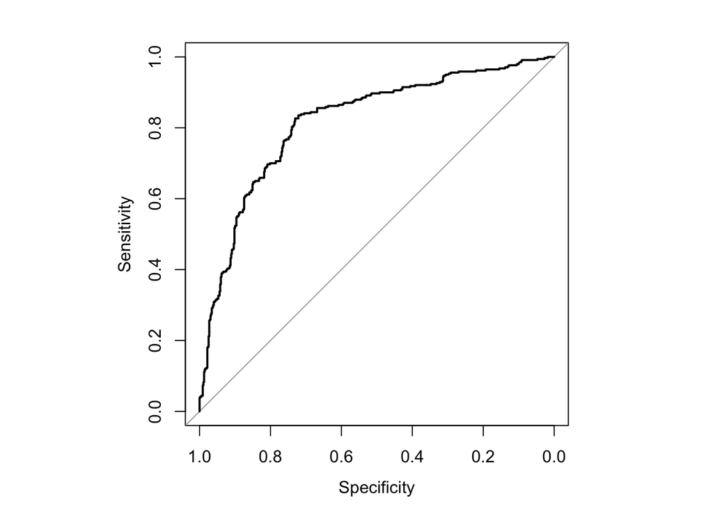

```r
par(pty="s")
plot(roc.nb)
```

```r
auc(roc.nb)
```

```
## Area under the curve: 0.8178
```

```r
test$Survived <- as.character(test$Survived)
test$Survived <- as.character(predict(model.nb, test))
test$Survived[test$Survived == 'X0'] <- 0
test$Survived[test$Survived == 'X1'] <- 1
submission.nb <- test %>% dplyr::select(PassengerId, Survived)
write.csv(submission.nb,"submission_nb.csv", row.names=FALSE) # 0.71531
```

## 7.7 Decision Tree

The criteria for a making (or not) a new split in a decision tree is to compare the decrease in the error of the tree with the new split against the **complexity parameter (cp)** times the number of leaves it would yield. If the former is greater, then the split is made.

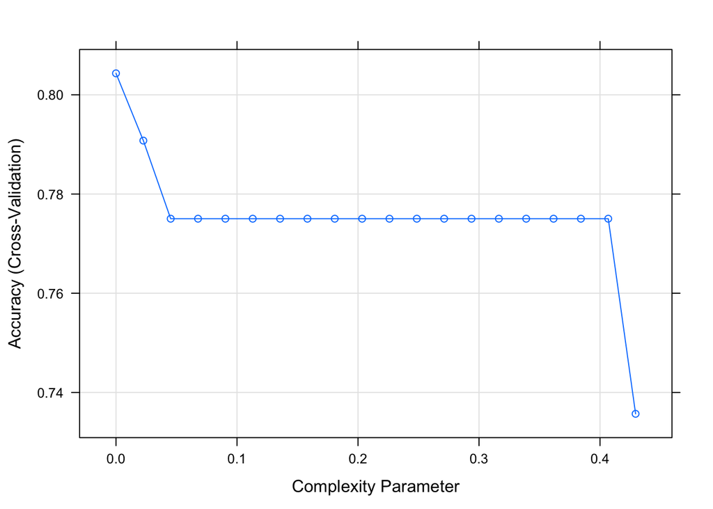

```r
library(rpart)
library(rpart.plot)
set.seed(1)

models.tree <- train(as.factor(Survived) ~ . - PassengerId, data=train, method="rpart", trControl=trainControl("cv", number=10), tuneLength=20)

# Plot model error vs different values of complexity parameter
plot(models.tree)
```

```r
# Print the best tuning parameter cp that minimize the model Accuracy
models.tree$bestTune
```

```
##   cp
## 1  0
```

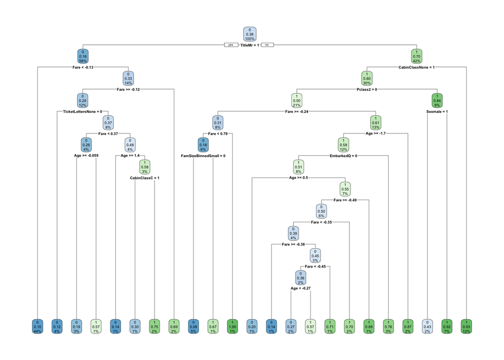

```r
# Plot the final tree model
rpart.plot(models.tree$finalModel)
```

```r
# Decision rules in the model
models.tree$finalModel
```

```
## n= 889
##
## node), split, n, loss, yval, (yprob)
##       * denotes terminal node
##
##    1) root 889 340 0 (0.61754781 0.38245219)
##      2) TitleMr>=0.5 517  81 0 (0.84332689 0.15667311)
##        4) Fare< -0.1338977 390  39 0 (0.90000000 0.10000000) *
##        5) Fare>=-0.1338977 127  42 0 (0.66929134 0.33070866)
##         10) Fare>=-0.1241159 111  31 0 (0.72072072 0.27927928)
##           20) TicketLettersNone< 0.5 40   5 0 (0.87500000 0.12500000) *
##           21) TicketLettersNone>=0.5 71  26 0 (0.63380282 0.36619718)
##             42) Fare< 0.3686371 38  10 0 (0.73684211 0.26315789)
##               84) Age>=-0.05919668 31   6 0 (0.80645161 0.19354839) *
##               85) Age< -0.05919668 7   3 1 (0.42857143 0.57142857) *
##             43) Fare>=0.3686371 33  16 0 (0.51515152 0.48484848)
##               86) Age>=1.41257 7   1 0 (0.85714286 0.14285714) *
##               87) Age< 1.41257 26  11 1 (0.42307692 0.57692308)
##                174) CabinClassC>=0.5 10   3 0 (0.70000000 0.30000000) *
##                175) CabinClassC< 0.5 16   4 1 (0.25000000 0.75000000) *
##         11) Fare< -0.1241159 16   5 1 (0.31250000 0.68750000) *
##      3) TitleMr< 0.5 372 113 1 (0.30376344 0.69623656)
##        6) CabinClassNone>=0.5 267 106 1 (0.39700375 0.60299625)
##         12) Pclass2< 0.5 187  93 1 (0.49732620 0.50267380)
##           24) Fare>=-0.2390822 68  21 0 (0.69117647 0.30882353)
##             48) Fare< 0.7922326 57  10 0 (0.82456140 0.17543860)
##               96) FamSizeBinnedSmall< 0.5 48   4 0 (0.91666667 0.08333333) *
##               97) FamSizeBinnedSmall>=0.5 9   3 1 (0.33333333 0.66666667) *
##             49) Fare>=0.7922326 11   0 1 (0.00000000 1.00000000) *
##           25) Fare< -0.2390822 119  46 1 (0.38655462 0.61344538)
##             50) Age>=-1.662917 104  44 1 (0.42307692 0.57692308)
##              100) EmbarkedQ< 0.5 75  37 1 (0.49333333 0.50666667)
##                200) Age>=0.5014765 10   2 0 (0.80000000 0.20000000) *
##                201) Age< 0.5014765 65  29 1 (0.44615385 0.55384615)
##                  402) Fare>=-0.4914765 56  28 0 (0.50000000 0.50000000)
##                    804) Fare< -0.3544919 36  14 0 (0.61111111 0.38888889)
##                     1608) Fare>=-0.3818239 7   1 0 (0.85714286 0.14285714) *
##                     1609) Fare< -0.3818239 29  13 0 (0.55172414 0.44827586)
##                       3218) Fare< -0.4513427 22   8 0 (0.63636364 0.36363636)
##                         6436) Age< -0.2694491 15   4 0 (0.73333333 0.26666667) *
##                         6437) Age>=-0.2694491 7   3 1 (0.42857143 0.57142857) *
##                       3219) Fare>=-0.4513427 7   2 1 (0.28571429 0.71428571) *
##                    805) Fare>=-0.3544919 20   6 1 (0.30000000 0.70000000) *
##                  403) Fare< -0.4914765 9   1 1 (0.11111111 0.88888889) *
##              101) EmbarkedQ>=0.5 29   7 1 (0.24137931 0.75862069) *
##             51) Age< -1.662917 15   2 1 (0.13333333 0.86666667) *
##         13) Pclass2>=0.5 80  13 1 (0.16250000 0.83750000)
##           26) Sexmale>=0.5 14   6 0 (0.57142857 0.42857143) *
##           27) Sexmale< 0.5 66   5 1 (0.07575758 0.92424242) *
##        7) CabinClassNone< 0.5 105   7 1 (0.06666667 0.93333333) *
```

```r
model.tree <- models.tree$finalModel
pred.tree <- predict(model.tree, train)
prob.tree <- pred.tree[,1]
class.tree <- rep("1", dim(train)[1])
class.tree[prob.tree > .5] = "0"

confusionMatrix(as.factor(class.tree), as.factor(train$Survived))
```

```
## Confusion Matrix and Statistics
##
##           Reference
## Prediction   0   1
##          0 501  71
##          1  48 269
##
##                Accuracy : 0.8661
##                  95% CI : (0.842, 0.8878)
##     No Information Rate : 0.6175
##     P-Value [Acc > NIR] : < 2e-16
##
##                   Kappa : 0.7129
##
##  Mcnemar's Test P-Value : 0.04372
##
##             Sensitivity : 0.9126
##             Specificity : 0.7912
##          Pos Pred Value : 0.8759
##          Neg Pred Value : 0.8486
##              Prevalence : 0.6175
##          Detection Rate : 0.5636
##    Detection Prevalence : 0.6434
##       Balanced Accuracy : 0.8519
##
##        'Positive' Class : 0
##
```

```r
roc.tree <- roc(response=train$Survived, predictor=prob.tree)
```

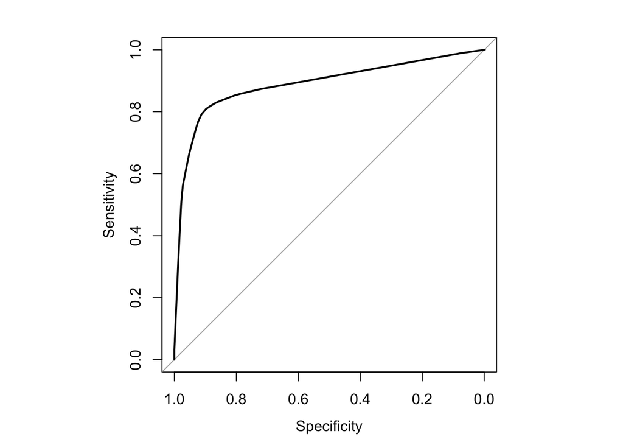

```r
par(pty="s")
plot(roc.tree)
```

```r
auc(roc.tree)
```

```
## Area under the curve: 0.8884
```

```r
test$Survived_ <- predict(model.tree, test)[,1]
test$Survived[test$Survived_ >  0.5] <- 0
test$Survived[test$Survived_ <= 0.5] <- 1
submission.tree <- test %>% dplyr::select(PassengerId, Survived)
write.csv(submission.tree,"submission_tree.csv", row.names=FALSE) # 0.73684
```

## 7.8 Random Forest

Here, we use 5-fold cross validation. **mtry** is the number of variables randomly sampled as candidates at each split.

```r
library(randomForest)
set.seed(5)
control <- trainControl(method="cv", number=5)
model.rf <- train(as.factor(Survived) ~ . -PassengerId, data=train, method="rf", trControl=control, tuneGrid=expand.grid(mtry=2:as.numeric(ncol(train)-2)))
model.rf$bestTune
```

```
##   mtry
## 6    7
```

```r
prob.rf <- predict(model.rf, train, type='prob')[,1]
class.rf <- rep("1", dim(train)[1])
class.rf[prob.rf > .5] = "0"
confusionMatrix(as.factor(class.rf), as.factor(train$Survived))
```

```
## Confusion Matrix and Statistics
##
##           Reference
## Prediction   0   1
##          0 542  32
##          1   7 308
##
##                Accuracy : 0.9561
##                  95% CI : (0.9405, 0.9686)
##     No Information Rate : 0.6175
##     P-Value [Acc > NIR] : < 2.2e-16
##
##                   Kappa : 0.9058
##
##  Mcnemar's Test P-Value : 0.0001215
##
##             Sensitivity : 0.9872
##             Specificity : 0.9059
##          Pos Pred Value : 0.9443
##          Neg Pred Value : 0.9778
##              Prevalence : 0.6175
##          Detection Rate : 0.6097
##    Detection Prevalence : 0.6457
##       Balanced Accuracy : 0.9466
##
##        'Positive' Class : 0
##
```

```r
roc.rf <- roc(response=train$Survived, predictor=prob.rf)
```

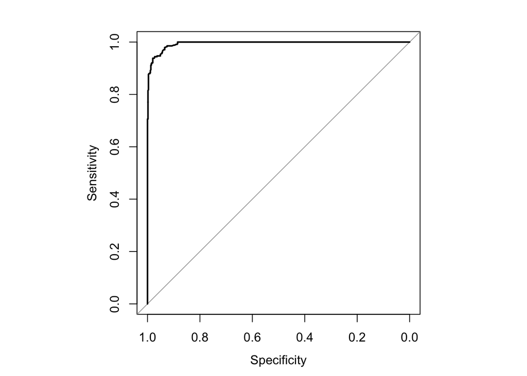

```r
par(pty="s")
plot(roc.rf)
```

```r
auc(roc.rf)
```

```
## Area under the curve: 0.9945
```

```r
test$Survived <- predict(model.rf, test)
submission.rf <- test %>% dplyr::select(PassengerId, Survived)
write.csv(submission.rf,"submission_rf.csv", row.names=FALSE) # 0.77272
```

We extract feature importance.

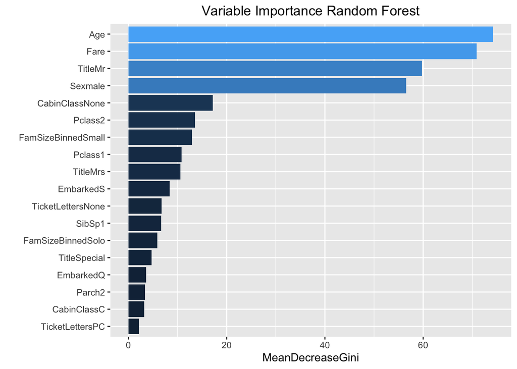

```r
# Extracting variable importance and make graph with ggplot (looks nicer that the standard varImpPlot)
rf_imp <- varImp(model.rf, scale = FALSE)
rf_imp <- rf_imp$importance
rf_gini <- data.frame(Variables = row.names(rf_imp), MeanDecreaseGini = rf_imp$Overall)
ggplot(rf_gini, aes(x=reorder(Variables, MeanDecreaseGini), y=MeanDecreaseGini, fill=MeanDecreaseGini)) +
        geom_bar(stat='identity') + coord_flip() + theme(legend.position="none") + labs(x="") +
        ggtitle('Variable Importance Random Forest') + theme(plot.title = element_text(hjust = 0.5))
```

## 7.9 XGBoost

```r
library(gbm)
set.seed(1)
control <- trainControl(method="cv", number=5)
model.gbm <- train(as.factor(Survived) ~ . -PassengerId, data=train, method='gbm', trControl=control, verbose=FALSE)
prob.gbm <- predict(model.gbm, train, type='prob')[,1]
class.gbm <- rep("1", dim(train)[1])
class.gbm[prob.gbm > .5] = "0"
confusionMatrix(as.factor(class.gbm), as.factor(train$Survived))
```

```
## Confusion Matrix and Statistics
##
##           Reference
## Prediction   0   1
##          0 499  74
##          1  50 266
##
##                Accuracy : 0.8605
##                  95% CI : (0.836, 0.8826)
##     No Information Rate : 0.6175
##     P-Value [Acc > NIR] : < 2e-16
##
##                   Kappa : 0.7007
##
##  Mcnemar's Test P-Value : 0.03888
##
##             Sensitivity : 0.9089
##             Specificity : 0.7824
##          Pos Pred Value : 0.8709
##          Neg Pred Value : 0.8418
##              Prevalence : 0.6175
##          Detection Rate : 0.5613
##    Detection Prevalence : 0.6445
##       Balanced Accuracy : 0.8456
##
##        'Positive' Class : 0
##
```

```r
roc.gbm <- roc(response=train$Survived, predictor=prob.gbm)
```

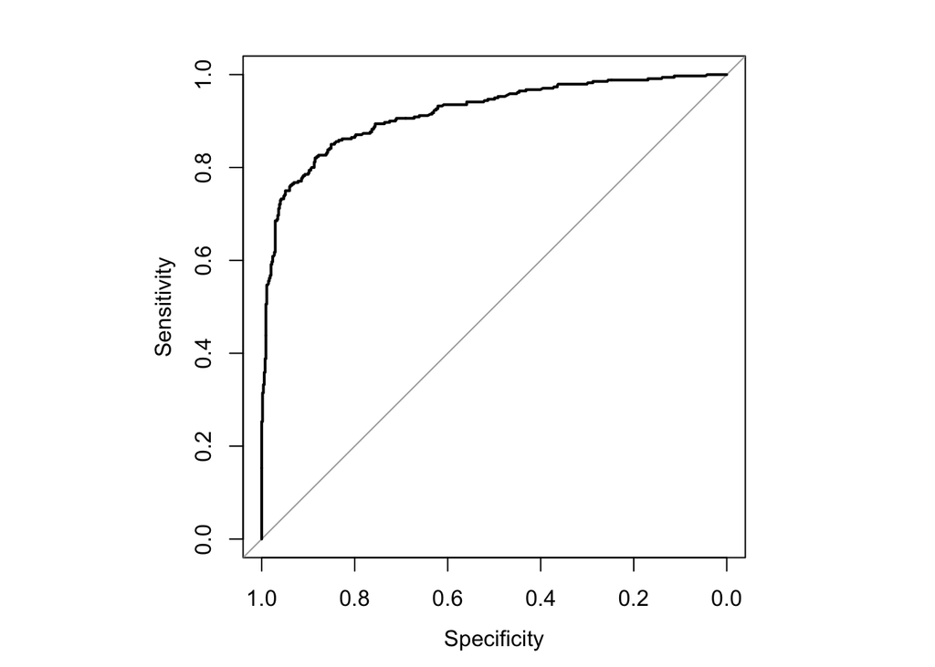

```r
par(pty="s")
plot(roc.gbm)
```

```r
auc(roc.gbm)
```

```
## Area under the curve: 0.9175
```

```r
test$Survived_ <- predict(model.gbm, test, type='prob')[,1]
test$Survived[test$Survived_ >  0.5] <- 0
test$Survived[test$Survived_ <= 0.5] <- 1
submission.gbm <- test %>% dplyr::select(PassengerId, Survived)
write.csv(submission.gbm,"submission_gbm.csv", row.names=FALSE) #
```

## 7.10 Neural Network

We use `caret`’s method `nnet` to run a 5-fold cross validation to find the best number of nodes and weight decay factor.

```r
library(neuralnet)
#http://sebastianderi.com/aexam/hld_MODEL_neural.html

set.seed(1)

# Step 1: SELECT TUNING PARAMETERS
# Set range of tuning parameters (layer size [number of nodes] and weight decay)
tune_grid_neural <- expand.grid(size=c(1:5), decay=c(0, 0.05, 0.1, 0.5, 1))

# Set other constrains to be imposed on network (to keep computation manageable)
max_size_neaural <- max(tune_grid_neural$size)
max_weights_neural <- max_size_neaural*(nrow(train) + 1) + max_size_neaural + 1

# Step 2: SELECT TUNING METHOD
# set up train control object, which specifies training/testing technique
control_neural <- trainControl(method="cv", number=5)

# Step 3: TRAIN MODEL
model.nn <- train(as.factor(Survived) ~ . -PassengerId, data=train, method="nnet", tuneGrid=tune_grid_neural, trControl=control_neural, trace=FALSE)
```

```r
prob.nn <- predict(model.nn, train, type='prob')[,1]
class.nn <- rep("1", dim(train)[1])
class.nn[prob.nn > .5] = "0"
confusionMatrix(as.factor(class.nn), as.factor(train$Survived))
```

```
## Confusion Matrix and Statistics
##
##           Reference
## Prediction   0   1
##          0 497  84
##          1  52 256
##
##                Accuracy : 0.847
##                  95% CI : (0.8216, 0.8701)
##     No Information Rate : 0.6175
##     P-Value [Acc > NIR] : < 2.2e-16
##
##                   Kappa : 0.6702
##
##  Mcnemar's Test P-Value : 0.007855
##
##             Sensitivity : 0.9053
##             Specificity : 0.7529
##          Pos Pred Value : 0.8554
##          Neg Pred Value : 0.8312
##              Prevalence : 0.6175
##          Detection Rate : 0.5591
##    Detection Prevalence : 0.6535
##       Balanced Accuracy : 0.8291
##
##        'Positive' Class : 0
##
```

```r
roc.nn <- roc(response=train$Survived, predictor=prob.nn)
```

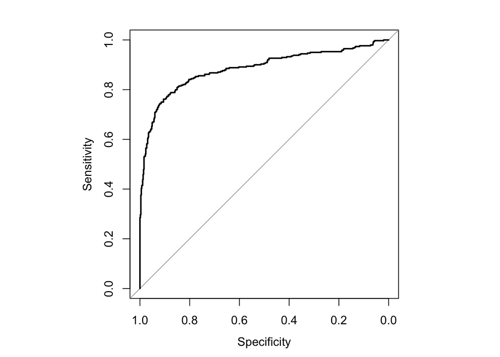

```r
par(pty="s")
plot(roc.nn)
```

```r
auc(roc.nn)
```

```
## Area under the curve: 0.884
```

```r
test$Survived_ <- predict(model.nn, test, type='prob')[,1]
test$Survived[test$Survived_ >  0.5] <- 0
test$Survived[test$Survived_ <= 0.5] <- 1
submission.nn <- test %>% dplyr::select(PassengerId, Survived)
write.csv(submission.nn,"submission_nn.csv", row.names=FALSE) # 0.77272
```

## 7.11 Combine Models

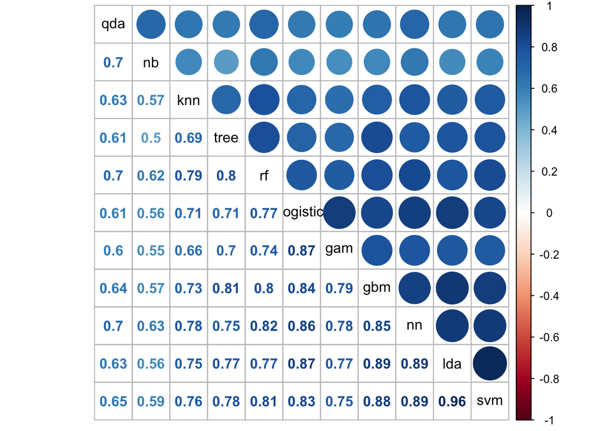

```r
#compose correlations plot
library(corrplot)
results <- as.data.frame(submission.lda[,1:2])
names(results)[1] <- 'PassengerId'
names(results)[2] <- 'lda'
results$qda <- submission.qda[,2]
results$logistic <- submission.logistic[,2]
results$knn <- submission.knn[,2]
results$gam <- submission.gam[,2]
results$svm <- submission.svm[,2]
results$nb <- submission.nb[,2]
results$tree <- submission.tree[,2]
results$rf <- submission.rf[,2]
results$gbm <- submission.gbm[,2]
results$nn <- submission.nn[,2]

results$lda <- as.numeric(as.character(results$lda))
results$qda <- as.numeric(as.character(results$qda))
results$knn <- as.numeric(as.character(results$knn))
results$svm <- as.numeric(as.character(results$svm))
results$nb <- as.numeric(results$nb)
results$tree <- as.numeric(results$tree)
results$rf <- as.numeric(as.character(results$rf))
results$gbm <- as.numeric(as.character(results$gbm))
results$nn <- as.numeric(as.character(results$nn))

corrplot.mixed(cor(results[, c('lda', 'qda', 'logistic', 'knn', 'gam', 'svm', 'nb', 'tree', 'rf', 'gbm', 'nn')]), order="hclust", tl.col="black")
```

```r
results <- results %>% mutate_if(is.numeric, ~replace(., is.na(.), 0))
results <- transform(results, majority=ifelse(lda+svm+gbm > 1, 1, 0))
submission.majority <- results %>% dplyr::select(PassengerId, majority)
names(submission.majority)[2] <- 'Survived'
write.csv(submission.majority,"submission_majority.csv", row.names=FALSE)
```

We take the LDA predictions unless both svm and gbm disagree with the lda prediction.

```r
submission.disagree.lda <- results %>% dplyr::select(PassengerId, lda, svm, gbm)
submission.disagree.lda$Survived <- ifelse(results$svm==results$gbm & results$lda!=results$svm, results$svm, results$lda)
submission.disagree.lda <- submission.disagree.lda %>% dplyr::select(PassengerId, Survived)
write.csv(submission.disagree.lda,"submission_disagree_lad.csv", row.names=FALSE)
```

To do: 1. Use different imputation for missing `Age`: e.g. KNN. 2. Use imputation for zero `Fare` (only 15 entries in train). 3. Create `SharedTicket` flag variable (only 6 tickets in train). 4. Create `IndependentPassenegr` flag variable. 5. Use something similar to AIC or BIC to eliminate some variables 6. Drop `Title` (drop `Name`)